# Fisher formalism to forecast kSZ SNR.

### Parameters constrained: 6 $\Lambda{\rm CDM}$ + $\alpha_{\rm radio}$ + $\sigma(\alpha_{\rm radio})$ + $A_{\rm CIB+tSZ}$ + $A_{\rm kSZ}^{h}$ + $\alpha_{\rm kSZ}^{h}$ + $z_{\rm re}^{\rm mid}$ + $\Delta z_{\rm re}$

#### Noise + foreground residuals: tSZ-free x CIB-free cross-ILC from, for example, publish/data/ilc_weights_residuals_agora_fg_model.npy

```python
%load_ext autoreload
%autoreload 2
```

```
The autoreload extension is already loaded. To reload it, use:
  %reload_ext autoreload
```

```python
import numpy as np, sys, os, scipy as sc, warnings
sys.path.append('modules/')
import tools, ilc, fisher_tools
import matplotlib.cbook
import scipy.ndimage as ndimage
warnings.filterwarnings("ignore", category=RuntimeWarning)
warnings.filterwarnings("ignore", category=DeprecationWarning)
warnings.filterwarnings("ignore", category=matplotlib.cbook.mplDeprecation)

#%pylab notebook
%matplotlib inline
from pylab import *

import copy
```

```python
rcParams['figure.dpi'] = 150
rcParams['figure.facecolor'] = 'white'
```

# Get the ILC residuals first

```python
#get the ILC residuals first
which_fg_model = 'agora'

fname = 'publish/ilc/ilc_weights_residuals_%s_fg_model.npy' %(which_fg_model)
ilc_dict = np.load(fname, allow_pickle = True).item()
print(ilc_dict.keys())

#get experiment Nl_dict
nl_TP_dict = ilc_dict['nl_TP_dict']

#different types of ILC considered
ilc_keyname_arr = ilc_dict['ilc_keyname_arr']
print(ilc_keyname_arr)

#ILC weights
weights_dict = ilc_dict['weights']
print(weights_dict.keys())

#total ILC residuals
total_ilc_residuals_dict = ilc_dict['total_ilc_residuals']
print(total_ilc_residuals_dict.keys())

if (1): #with CCAT-prime
    fname_withccatp = 'publish/ilc/ilc_weights_residuals_%s_fg_model_withccatp.npy' %(which_fg_model)
    ilc_dict_withccatp = np.load(fname_withccatp, allow_pickle = True).item()

    weights_dict_withccatp = ilc_dict_withccatp['weights']

    #get experiment Nl_dict
    nl_TP_dict_withccatp = ilc_dict_withccatp['nl_TP_dict']

    #total ILC residuals
    total_ilc_residuals_dict_withccatp = ilc_dict_withccatp['total_ilc_residuals']
    #print(total_ilc_residuals_dict.keys())

    ##print(ilc_dict_withccatp.keys())

#el range
els = ilc_dict['el']
```

```
dict_keys(['weights', 'total_ilc_residuals', 'cib_plus_tsz_residuals', 'cib_residuals', 'tsz_residuals', 'noise_residuals', 'radio_residuals', 'nl_TP_dict', 'cl_signal_plus_noise', 'ilc_keyname_arr', 'el'])
['mv' 'tszfree' 'cibfree' 'mvxcibfree' 'mvxtszfree' 'tszfreexcibfree']
dict_keys(['s4_wide', 's4_deep', 'spt3g', 'spt4', 'so_baseline', 'so_goal'])
dict_keys(['s4_wide', 's4_deep', 'spt3g', 'spt4', 'so_baseline', 'so_goal'])
```

# Experiment names and $f_{\rm sky}$ values

```python
#experiment names and fsky values
exp_specs_dict = {
                  's4_wide': ['S4-Wide', 0.57, 'black'],
                  #'s4_wide_withccatp': ['S4-Wide + FYST', 0.57],
                  's4_deep': ['S4-Ultra Deep', 0.03, 'darkred'],
                  'spt3g': ['SPT-3G', 0.03, 'darkgreen'],
                  'spt4': ['SPT-3G+SPT-4', 0.03, 'tab:green'],
                  'so_baseline': ['SO-Baseline', 0.4, 'royalblue'],
                  'so_baseline_withccatp': ['SO-Baseline + FYST', 0.4, 'tab:blue'],
                  'so_goal': ['SO-Goal', 0.4, 'darkorange'],
                  'so_goal_withccatp': ['SO-Goal + FYST', 0.4, 'tab:orange'],
                  }

#ILC keynames
ilc_keyname_dict = {'mv':'MV', 'tszfree': 'tSZ-free', 'cibfree': 'CIB-free'}
```

# Setting variables for Fisher forecasting

### Default cosmology: $\texttt{planck_cosmo_version}$ = ${\it Planck}$ 2018.

### Param file used for CAMB: publish/data/params_planck_r_0.0_2018_cosmo.txt

### TT, TE, EE + lowE + lensing in Table 2 of 1807.06209

### ${\it Planck}$ 2015 is also available.

### Radio residuals are modelled using two parameters:

#### $\alpha_{\rm rad} = -0.76$: Mean spectral index of sources.

#### $\sigma(\alpha_{\rm rad}) = 0.2$: Scatter in the spectral index of sources.

### Left over CIB+tSZ residuals are modelled using a single amplitude parameter $A_{\rm CIB+tSZ}=1$.

```python
#some variables for Fisher forecasting
#expname = 's4_wide'
#fsky = exp_specs_dict[expname][1]
planck_cosmo_version = 2018 ##2015 #2018
camb_folder = 'publish/data/CAMB/planck_%s/' %(planck_cosmo_version)
which_spectra = 'lensed'
reqd_ilc_keyname_1 = 'tszfree'
reqd_ilc_keyname_2 = 'cibfree'
max_flux_mJy = 3e-3 #masking threshold used.
if reqd_ilc_keyname_1 != reqd_ilc_keyname_2:
    reqd_ilc_keyname_12 = '%sx%s' %(reqd_ilc_keyname_1, reqd_ilc_keyname_2)
else:
    reqd_ilc_keyname_12 = reqd_ilc_keyname_1

#radio-related stuffs
spec_index_radio = -0.76 #Radio spectral index fiducial value
spec_index_radio_step = spec_index_radio/100. #stpe for derivative calculation
spec_index_radio_prior = 0.1 #Radio spectral index prior
alpha_radio = spec_index_radio

spec_index_radio_scatter = 0.2 #Radio spectral index fiducial scatter
spec_index_radio_scatter_step = spec_index_radio_scatter/100.
spec_index_radio_scatter_prior = 0.3 #Radio spectral index scatter prior
alpha_radio_sigma = spec_index_radio_scatter

#CIB+tSZ residuals
Acibtsz = 1.
Acibtsz_step = Acibtsz/100.
```

## What kind of freocasting are we doing? This gets set by the variable $\texttt{constrain_reion}$. The others parameters gets set accordingly.

### Just kSZ SNR --> $\texttt{constrain_reion} = False$

### Reionisation constraints. --> $\texttt{constrain_reion} = True$

## kSZ SNR:

### A single $A_{\rm kSZ} = 1$ is assumed for the amplitude of the kSZ power spectrum.

### $D_{\ell}^{\rm kSZ} = A_{\rm kSZ} \times 3 \mu {\rm K}^2$.

## Reionisation: In this case, we use 4 parameters. 2 for local homogeneous kSZ and 2 for late-time patchy kSZ.

### $\alpha_{\rm ksz}^{\rm h} = 0$ is the tilt.

### $\ell_{\rm norm}=3000$ is the pivot.

### Patchy kSZ: Modelled using [AMBER (Chen et al. 2022)](https://arxiv.org/abs/2203.04337) simulations. Parameters used for modelling are

### $z_{\rm re}^{\rm mid} = 7.69$ is the midpoint of reionisation where the fiducial value corresponds to ${\it Planck}$ 2018 results $\tau_{\rm re} = 0.0544$.

### $\Delta z_{\rm re} = 4$ is the duration of reionisation.

### This roughly gives $D_{\ell}^{\rm p-kSZ} \sim 1.5 \mu {\rm K}^2$ and so the total kSZ is roughly $D_{\ell}^{\rm kSZ} = D_{\ell}^{\rm h-kSZ} + D_{\ell}^{\rm p-kSZ} \sim 3 \mu {\rm K}^2$.

### Check publish/data/cl_patchy_ksz_amber_derivatives.npy.

```python
#ksz-related stuffs.
constrain_reion = False #True #False #True ####False ##True
if constrain_reion:
    fisher_opfname = 'publish/fisher/F_mat_results_reion.npy'
else:
    fisher_opfname = 'publish/fisher/F_mat_results_totalksz.npy'

redo_fisher = False

#parameters for total kSZ SNR
dl_ksz_amp_total = 3. #D_{\ell}^{\rm kSZ} = 3 uK^2
Aksz = 1. #Amplitude of kSZ.
Aksz_step = Aksz / 100. #stpe for derivative calculation

#parameters for homogeneous and reionisation kSZ.
#homogeneous kSZ - similar to Alvarez et al. 2020
Aksz_h = 1.5
alphaksz_h = 0.
Aksz_h_step = Aksz_h/100.
alphaksz_h_step = 0.01

#patchy kSZ part
##zmid = 8.
import tools_for_plotting
import camb
param_dict = tools_for_plotting.get_ini_param_dict()
#print(param_dict)
pars = camb.CAMBparams(max_l_tensor = param_dict['max_l_tensor'], max_eta_k_tensor = param_dict['max_eta_k_tensor'])
pars.set_accuracy(AccuracyBoost = param_dict['AccuracyBoost'], lAccuracyBoost = param_dict['lAccuracyBoost'], lSampleBoost = param_dict['lSampleBoost'],\
    DoLateRadTruncation = param_dict['do_late_rad_truncation'])
pars.set_cosmology(thetastar=param_dict['thetastar'], ombh2=param_dict['ombh2'], omch2=param_dict['omch2'], nnu = param_dict['neff'], mnu=param_dict['mnu'], \
    omk=param_dict['omk'], tau=param_dict['tau'], YHe = param_dict['YHe'], Alens = param_dict['Alens'], \
    num_massive_neutrinos = param_dict['num_nu_massive'])

zmid = camb.get_zre_from_tau(pars,param_dict['tau'])
zdur = 4.
if (0): #precomputed.
    zmid_step = zmid/100.
    zdur_step = zdur/100.
```

## Pick CMB $C_{\ell}^{\rm xx}$ and derivatives $\dfrac{\partial C_{\ell}^{\rm XX}}{\partial \theta}$ where ${\rm XX} \in [TT, EE, TE]$ and $\theta \in [A_{s},\ h,\ n_{s},\ \Omega_{c}h^{2},\ \Omega_{b}h^{2},\ \tau_{\rm re}]$

### Note:

- $C_{\ell}$ and the derivatives are already stored and also contain additional parameters namely $\sum m_{\nu}$ and $w_{0}$. Both these parameters are fixed during Fisher forecasting.
- Paramters that are added later (below):
  - $A_{\rm kSZ}$ - Amplitude of the kSZ power spectrum $D_{\ell} = 3 \mu {\rm K}^{2}$.
  - $\alpha_{\rm rad}$ - Spectral index of radio point sources.
  - $\sigma(\alpha_{\rm rad})$ - Scatter in the distribution of spectral indices of the radio point sources.

```python
#CMB stuffs
#get fiducual LCDM power spectra computed using CAMB
print('get fiducual LCDM power spectra computed using CAMB')
camb_fname = '%s/cmb_spectra_%s.txt' %(camb_folder, which_spectra)
cl_camb = np.loadtxt(camb_fname)
el_camb = cl_camb[:,0]
cl_camb_tt = cl_camb[:,1]
dl_fac_camb = el_camb * (el_camb+1)/2/np.pi
cl_dic = {}
cl_dic['TT'] = cl_camb[:,1]
cl_dic['EE'] = cl_camb[:,2]
cl_dic['TE'] = cl_camb[:,3]

#get derivatives of CMB power spectrum for different LCDM parameters.
#They are already computed and stored.
print('get/read derivatives')
camb_deriv_fname = '%s/cmb_spectra_derivs_%s.npy' %(camb_folder, which_spectra)
cl_deriv_dic_tmp = np.load(camb_deriv_fname, allow_pickle = 1).item()
cl_deriv_dic = {}
param_names = []
for p in sorted( cl_deriv_dic_tmp ):
    if p == 'ell': continue
    cl_deriv_dic[p]={}
    if planck_cosmo_version == 2018:
        cl_deriv_dic[p]['TT'] = cl_deriv_dic_tmp[p]['TT']
        cl_deriv_dic[p]['EE'] = cl_deriv_dic_tmp[p]['EE']
        cl_deriv_dic[p]['TE'] = cl_deriv_dic_tmp[p]['TE']
    else:
        cl_deriv_dic[p]['TT'] = cl_deriv_dic_tmp[p][0]
        cl_deriv_dic[p]['EE'] = cl_deriv_dic_tmp[p][1]
        cl_deriv_dic[p]['TE'] = cl_deriv_dic_tmp[p][2]

    if p == 'As' and planck_cosmo_version == 2015:
        cl_deriv_dic[p]['TT'] *= 1e9
        cl_deriv_dic[p]['EE'] *= 1e9
        cl_deriv_dic[p]['TE'] *= 1e9

    param_names.append( p )

#interpolate CAMB spectra / derivatives on the desired els.
for which_spec in cl_dic:
    cl_dic[which_spec] = np.interp(els, el_camb, cl_dic[which_spec], right=0.)
for p in sorted( param_names ):
    for which_spec in cl_deriv_dic[p]:
        cl_deriv_dic[p][which_spec] = np.interp(els, el_camb, cl_deriv_dic[p][which_spec], right=0.)

cl_dic_cmb = copy.deepcopy(cl_dic)
```

```
get fiducual LCDM power spectra computed using CAMB
get/read derivatives
```

[output not shown]

## Sanity check - Compare derivatives $\dfrac{\partial C_{\ell}^{\rm XX}}{\partial \theta}$ from ${\it Planck}$ 2015 vs 2018 cosmology.

```python
if (0): #compare 2015 and 2018 derivatives
    planck_cosmo_version_arr = [2015, 2018]
    parent_cl_deriv_dic = {}
    for planck_cosmo_version in planck_cosmo_version_arr:
        camb_deriv_fname = 'publish/data/CAMB/planck_%s/cmb_spectra_derivs_%s.npy' %(planck_cosmo_version, which_spectra)
        cl_deriv_dic_tmp = np.load(camb_deriv_fname, allow_pickle = 1).item()
        cl_deriv_dic = {}
        param_names = []
        for p in sorted( cl_deriv_dic_tmp ):
            if p == 'ell': continue
            cl_deriv_dic[p]={}
            if planck_cosmo_version == 2018:
                cl_deriv_dic[p]['TT'] = cl_deriv_dic_tmp[p]['TT']
                cl_deriv_dic[p]['EE'] = cl_deriv_dic_tmp[p]['EE']
                cl_deriv_dic[p]['TE'] = cl_deriv_dic_tmp[p]['TE']
            else:
                cl_deriv_dic[p]['TT'] = cl_deriv_dic_tmp[p][0]
                cl_deriv_dic[p]['EE'] = cl_deriv_dic_tmp[p][1]
                cl_deriv_dic[p]['TE'] = cl_deriv_dic_tmp[p][2]

            if p == 'As' and planck_cosmo_version == 2015:
                cl_deriv_dic[p]['TT'] *= 1e9
                cl_deriv_dic[p]['EE'] *= 1e9
                cl_deriv_dic[p]['TE'] *= 1e9

            param_names.append( p )
        parent_cl_deriv_dic[planck_cosmo_version] = cl_deriv_dic
        print(param_names)

    for p in ['As', 'mnu', 'neff', 'ns', 'ombh2', 'omch2', 'tau', 'thetastar']:
    #for p in ['thetastar']:
        clf()
        ax = subplot(111, yscale = 'log')
        which_spec_dict = {'TT': 'navy', 'EE': 'darkgreen', 'TE': 'darkred'}
        for which_spec in which_spec_dict:
            der2015 = parent_cl_deriv_dic[2015][p][which_spec]
            der2018 = parent_cl_deriv_dic[2018][p][which_spec]
            plot(abs(der2018), color = which_spec_dict[which_spec], ls = '-')
            plot(abs(der2015), color = which_spec_dict[which_spec], ls = '--', lw = 4.)
        show(); sys.exit()
```

## Get the kSZ temperature power spectrum $C_{\ell}^{\rm kSZ}$ and the derivatives:

### Total kSZ SNR: $\dfrac{\partial C_{\ell}^{\rm kSZ}}{\partial A_{\rm kSZ}}$.

### Reionisation kSZ: $\dfrac{\partial C_{\ell}^{\rm kSZ}}{\partial \theta}$ where $\theta \in [A_{\rm ksz}^{\rm h}, \alpha_{\rm ksz}^{\rm h}, z_{\rm re}^{\rm mid}, \Delta z_{\rm re}]$.

### Note:

### We assume that the derivatives of $C_{\ell}^{\rm kSZ}$ w.r.t $\Lambda CDM$ parameters is zero.

### This is not fully correct.

### We also assume that the derivatives of CMB power spectrum $C_{\ell}^{\rm TT}$ w.r.t $A_{\rm kSZ}$ is zero.

### We set EE and TE part of $C_{\ell}^{\rm kSZ} = 0$.

```python
#kSZ stuffs
print('get kSZ spectrum and derivatives')
"""
Assumptions:
1. We assume that the derivatives of cl_kSZ w.r.t LCDM parameters is zero.
    (A) This is not 100 per cent true.
2. We also assume that the derivatives of CMB power spectrum w.r.t AkSZ is zero.
    (A) This is a reasonable assumption.
"""

if not constrain_reion: #constrain total kSZ ampltiude.

    #get kSZ spectrum now: Flat D_{\ell}^{\rm kSZ} = 3 uK^2
    cl_ksz = fisher_tools.get_cl_ksz(els, Aksz = Aksz, dl_ksz_amp_total = dl_ksz_amp_total)

    #add kSZ to cl_dic['TT']
    cl_dic['TT'] += cl_ksz

    #get deriviatives for Aksz
    cl_ksz_low = fisher_tools.get_cl_ksz(els, Aksz = Aksz - Aksz_step, dl_ksz_amp_total = dl_ksz_amp_total)
    cl_ksz_high = fisher_tools.get_cl_ksz(els, Aksz = Aksz + Aksz_step, dl_ksz_amp_total = dl_ksz_amp_total)
    cl_deriv_dic['Aksz'] = {}
    cl_deriv_dic['Aksz']['TT'] = (cl_ksz_high-cl_ksz_low)/( 2 * Aksz_step)
    cl_deriv_dic['Aksz']['EE'] = cl_deriv_dic['Aksz']['TT'] * 0.
    cl_deriv_dic['Aksz']['TE'] = cl_deriv_dic['Aksz']['TT'] * 0.

else: #constrain local and reionisation kSZ parameters.

    #get homogeneous kSZ first
    el_norm = 3000.
    cl_ksz_homo = fisher_tools.get_homo_ksz(els, Aksz_h = Aksz_h, alphaksz_h = alphaksz_h, el_norm = el_norm)
    #add cl_ksz_homo to cl_dic['TT']
    cl_dic['TT'] += cl_ksz_homo
    #get derivatives
    #Aksz_h first
    cl_ksz_homo_low = fisher_tools.get_homo_ksz(els, Aksz_h = Aksz_h - Aksz_h_step, alphaksz_h = alphaksz_h, el_norm = el_norm)
    cl_ksz_homo_high = fisher_tools.get_homo_ksz(els, Aksz_h = Aksz_h + Aksz_h_step, alphaksz_h = alphaksz_h, el_norm = el_norm)
    cl_deriv_dic['Aksz_h'] = {}
    cl_deriv_dic['Aksz_h']['TT'] = (cl_ksz_homo_high-cl_ksz_homo_low)/( 2 * Aksz_h_step)
    cl_deriv_dic['Aksz_h']['EE'] = cl_deriv_dic['Aksz_h']['TT'] * 0.
    cl_deriv_dic['Aksz_h']['TE'] = cl_deriv_dic['Aksz_h']['TT'] * 0.
    #alphaksz_h now
    cl_ksz_homo_low = fisher_tools.get_homo_ksz(els, Aksz_h = Aksz_h, alphaksz_h = alphaksz_h - alphaksz_h_step, el_norm = el_norm)
    cl_ksz_homo_high = fisher_tools.get_homo_ksz(els, Aksz_h = Aksz_h, alphaksz_h = alphaksz_h + alphaksz_h_step, el_norm = el_norm)
    cl_deriv_dic['alphaksz_h'] = {}
    cl_deriv_dic['alphaksz_h']['TT'] = (cl_ksz_homo_high-cl_ksz_homo_low)/( 2 * alphaksz_h_step)
    cl_deriv_dic['alphaksz_h']['EE'] = cl_deriv_dic['alphaksz_h']['TT'] * 0.
    cl_deriv_dic['alphaksz_h']['TE'] = cl_deriv_dic['alphaksz_h']['TT'] * 0.

    #get patchy kSZ now (from precomputed file.)
    patchy_ksz_fname = 'publish/data/cl_patchy_ksz_amber_derivatives.npy'
    patchy_ksz_dict = np.load(patchy_ksz_fname, allow_pickle = True).item()
    els_, cl_ksz_patchy = patchy_ksz_dict['els'], patchy_ksz_dict['cl_ksz_patchy']
    cl_ksz_patchy = np.interp(els, els_, cl_ksz_patchy)
    #add cl_ksz_patchy to cl_dic['TT']
    cl_dic['TT'] += cl_ksz_patchy

    if (0):
        dl_fac = els * (els+1)/2/np.pi
        ax = subplot(111, yscale='log')
        plot(els, dl_fac * cl_dic_cmb['TT'], color = 'gray')
        plot(els, dl_fac * cl_ksz_homo, color = 'orangered')
        plot(els, dl_fac * cl_ksz_patchy, color = 'goldenrod')
        plot(els, dl_fac * cl_dic['TT'], color = 'black')
        xlim(0., 5000.); ylim(0.1, 1e4)
        show(); sys.exit()

    #derivatives
    cl_ksz_patchy_deriv = patchy_ksz_dict['cl_ksz_patchy_deriv']
    for tmp_p in cl_ksz_patchy_deriv:
        curr_cl_ksz_patchy_deriv = cl_ksz_patchy_deriv[tmp_p]
        curr_cl_ksz_patchy_deriv = np.interp(els, els_, curr_cl_ksz_patchy_deriv)
        cl_deriv_dic[tmp_p] = {}
        cl_deriv_dic[tmp_p]['TT'] = curr_cl_ksz_patchy_deriv
        cl_deriv_dic[tmp_p]['EE'] = curr_cl_ksz_patchy_deriv * 0.
        cl_deriv_dic[tmp_p]['TE'] = curr_cl_ksz_patchy_deriv * 0.

#store this in a different dict for future use.
#We will add experiment dependent radio residuals below which will change this dictionary.
cl_dic_ori = copy.deepcopy(cl_dic)
cl_deriv_dic_ori = copy.deepcopy(cl_deriv_dic)
```

```
get kSZ spectrum and derivatives
```

# Define some functions.

#### $\texttt{get_temperature_ilc_residuals}$ - Get the temperature ILC residuals from the ILC dictionary read/stored earlier.

#### $\texttt{get_polarisation_mvilc_residuals}$ - Compute the MV-ILC residuals in polarisation for the desried experiment.

#### $\texttt{get_exp_bands}$ - Get frqeuency bands for the desired experiment.

#### $\texttt{wrapper_get_delta_cl}$ - Wrapper to obtain $\Delta C_{\ell}$.

#### $\texttt{get_radio_residuals}$ - Get ILC radio residuals $C_{\ell}^{\rm rad}$ for the desired experiment.

#### $\texttt{get_radio_spectrum_and_derivatives}$ - Get derivatives of radio power spectrum residuals $\dfrac{\partial C_{\ell}^{\rm rad}}{\partial \theta}$ where $\theta \in [\alpha_{\rm rad}, \sigma(\alpha_{\rm rad})]$.

#### $\texttt{get_cib_tsz_spectrum_and_derivatives}$ - Get derivatives of CIB+tSZ power spectrum residuals $\dfrac{\partial C_{\ell}^{\rm CIB+tSZ}}{\partial A_{\rm cib+tsz}}$.

```python
def get_temperature_ilc_residuals(expname, reqd_ilc_keyname_1, reqd_ilc_keyname_2, quiet = False): #Temperature ILC residuals for Nl
    if not quiet:
        print('\tget ILC residuals for Nl')
    if expname.find('withccatp')>-1:
        dict_to_use = total_ilc_residuals_dict_withccatp
        expname_to_use = expname.replace('_withccatp', '')
    else:
        dict_to_use = total_ilc_residuals_dict
        expname_to_use = expname
    if reqd_ilc_keyname_1 != reqd_ilc_keyname_2:
        reqd_ilc_keyname_12 = '%sx%s' %(reqd_ilc_keyname_1, reqd_ilc_keyname_2)
    else:
        reqd_ilc_keyname_12 = reqd_ilc_keyname_1
    els, total_ilc_residual_mv = dict_to_use[expname_to_use]['mv']
    els, total_ilc_residual_1 = dict_to_use[expname_to_use][reqd_ilc_keyname_1]
    els, total_ilc_residual_2 = dict_to_use[expname_to_use][reqd_ilc_keyname_2]
    els, total_ilc_residual_12 = dict_to_use[expname_to_use][reqd_ilc_keyname_12]

    return els, total_ilc_residual_mv, total_ilc_residual_1, total_ilc_residual_2, total_ilc_residual_12

def get_polarisation_mvilc_residuals(expname):
    #get MV-ILC for polarisation
    """
    Note that foregrounds are assumed to be unpolarised here.
    So this should simply be a MV noise estimate after taking beams into account.
    """
    dict_for_ilc = {}
    if expname.find('withccatp')>-1:
        expname_to_use = expname.replace('_withccatp', '')
        dict_for_ilc['EE'] = nl_TP_dict_withccatp[expname_to_use]['P']
    else:
        dict_for_ilc['EE'] = nl_TP_dict[expname]['P']
    bands = get_exp_bands(expname)
    mvilc_pol_residuals, mvilc_pol_weights = ilc.get_mvilc_residual_and_weights(bands, els, dict_for_ilc)
    mvilc_pol_residuals = mvilc_pol_residuals[0]

    if (0):#expname == 's4_wide': #show plot for MV-ILC for pol and compare that will noise.
        clf()
        fsval = 14
        band_color_dict = {95: 'navy', 150: 'darkgreen', 220: 'goldenrod', 285: 'orangered', 345: 'darkred',
                            '410': 'hotpink', 850: 'black'}
        ax=subplot(111, yscale = 'log')
        noise_arr = []
        for (nu1, nu2) in dict_for_ilc['EE']:
            if nu1 != nu2: continue
            curr_nl = dict_for_ilc['EE'][(nu1, nu2)]

            plot(els, curr_nl, color = band_color_dict[nu1], label = r'%s GHz' %(nu1))
            noise_arr.append(curr_nl)

        #MV-ILC for pol
        plot(els, mvilc_pol_residuals, color = 'black', label = r'MV-ILC')

        if (0): #simple MV noise for pol as a sanity check.
            noise_arr = np.asarray(noise_arr)
            mv_noise_pol = ( np.sum(noise_arr**-2, axis = 0) )**-0.5
            plot(els, mv_noise_pol, color = 'hotpink', lw = 2., ls = '-.', label = r'MV noise for pol.')

        legend(loc = 1, fontsize = fsval - 6, ncol = 5)
        xlabel(r'Multipole $\ell$', fontsize = fsval)
        ylabel(r'Polarisation noise: $C_{\ell}$ [$\mu$K$^{2}$]', fontsize = fsval-2)
        xlim(0., 7000.); ylim(1e-7, .01)
        title_str = r'%s: Polarisation noise + MV-ILC' %(exp_specs_dict[expname][0])
        title(title_str, fontsize = fsval)
        show()

    return els, mvilc_pol_residuals

def get_exp_bands(expname):
    if expname in ['s4_wide', 's4_deep', 'so_baseline', 'so_goal']:
        bands = [95, 150, 220, 285]
    elif expname == 'spt3g':
        bands = [95, 150, 220]#, 600, 857]
    elif expname == 'spt4':
        bands = [95, 150, 220, 285, 345]
    elif expname in ['s4_wide_withccatp', 'so_baseline_withccatp', 'so_goal_withccatp']:
        bands = [95, 150, 220, 285, 345, 410, 850]

    return bands

def wrapper_get_delta_cl(els, cl_dic, fsky,
                            total_ilc_residual_1, total_ilc_residual_2, total_ilc_residual_12,
                            total_ilc_residual_mv, mvilc_pol_residuals,
                           ):
    #get delta_Cl using Knox formula.
    nl11_dic = {}
    nl11_dic['TT'] = total_ilc_residual_1
    nl11_dic['EE'] = mvilc_pol_residuals
    nl11_dic['TE'] = np.copy(total_ilc_residual_1) * 0.

    nl22_dic = {}
    nl22_dic['TT'] = total_ilc_residual_2
    nl22_dic['EE'] = mvilc_pol_residuals
    nl22_dic['TE'] = np.copy(total_ilc_residual_2) * 0.

    nl12_dic = {}
    nl12_dic['TT'] = total_ilc_residual_12
    nl12_dic['EE'] = mvilc_pol_residuals
    nl12_dic['TE'] = np.copy(total_ilc_residual_12) * 0.

    delta_cl_dic = fisher_tools.get_knox_errors_parent(els, cl_dic, nl11_dic, fsky, nl22_dic = nl22_dic, nl12_dic = nl12_dic)
    #print(delta_cl_dic.keys())

    if (1): #MV ILC
        nl_mv_dic = {}
        nl_mv_dic['TT'] = total_ilc_residual_mv
        nl_mv_dic['EE'] = mvilc_pol_residuals
        nl_mv_dic['TE'] = np.copy(total_ilc_residual_mv) * 0.
        delta_cl_dic_mv = fisher_tools.get_knox_errors_parent(els, cl_dic, nl_mv_dic, fsky)
        #print(delta_cl_dic_mv.keys())

    return delta_cl_dic, delta_cl_dic_mv


#radio stuffs
def get_radio_residuals(expname, which_dnds = 'lagache',
                        min_flux_mJy=0.1e-3, max_flux_mJy = 3e-3,
                        spec_index_radio = -0.76,
                        spec_index_radio_scatter = 0.2,
                        quiet = True):
    #get radio spectrum now for a given masking threshold.
    if expname.find('withccatp')>-1:
        expname_to_use = expname.replace('_withccatp', '')
        w1, w2 = weights_dict_withccatp[expname_to_use][reqd_ilc_keyname_1], weights_dict_withccatp[expname_to_use][reqd_ilc_keyname_2] #weights for the two ILC maps.
    else:
        expname_to_use = expname
        w1, w2 = weights_dict[expname_to_use][reqd_ilc_keyname_1], weights_dict[expname_to_use][reqd_ilc_keyname_2] #weights for the two ILC maps.
    bands = get_exp_bands(expname)
    ##print(bands, len(bands), w1.shape, w2.shape); sys.exit()
    radio_cl_dict = tools.get_radio_ilc_residuals(els, bands, w1, w2, [which_dnds],
                                                  min_flux_mJy = min_flux_mJy, max_flux_mJy = max_flux_mJy,
                                                  spec_index_radio = spec_index_radio,
                                                  spec_index_radio_scatter_arr = [spec_index_radio_scatter],
                                                 quiet = quiet)

    res_cl_radio = radio_cl_dict[which_dnds][spec_index_radio_scatter]['res_ilc']

    return res_cl_radio

def get_radio_spectrum_and_derivatives(expname, cl_dic, cl_deriv_dic, which_dnds = 'lagache',
                        min_flux_mJy=0.1e-3, max_flux_mJy = 3e-3,
                        spec_index_radio = -0.76,
                        spec_index_radio_scatter = 0.2,
                        quiet = True):

    #get radio spectrum
    if not quiet: print('get radio spectrum')
    cl_radio = get_radio_residuals(expname, max_flux_mJy = max_flux_mJy, spec_index_radio = spec_index_radio, spec_index_radio_scatter = spec_index_radio_scatter, quiet=quiet)
    #add radio to cl_dic['TT']
    ##cl_dic['TT'] += cl_radio## - already included in total residuals.

    #get deriviatives for spec_index_radio
    if not quiet: print('get deriviatives for alpha_radio')
    cl_radio_alpha_radio_low = get_radio_residuals(expname, max_flux_mJy = max_flux_mJy, spec_index_radio = spec_index_radio - spec_index_radio_step, spec_index_radio_scatter = spec_index_radio_scatter, quiet=quiet)
    cl_radio_alpha_radio_high = get_radio_residuals(expname, max_flux_mJy = max_flux_mJy, spec_index_radio = spec_index_radio + spec_index_radio_step, spec_index_radio_scatter = spec_index_radio_scatter, quiet=quiet)
    cl_deriv_dic['alpha_radio'] = {}
    cl_deriv_dic['alpha_radio']['TT'] = (cl_radio_alpha_radio_high-cl_radio_alpha_radio_low)/( 2 * spec_index_radio_step)
    cl_deriv_dic['alpha_radio']['EE'] = cl_deriv_dic['alpha_radio']['TT'] * 0.
    cl_deriv_dic['alpha_radio']['TE'] = cl_deriv_dic['alpha_radio']['TT'] * 0.

    #get deriviatives for spec_index_radio_scatter
    if not quiet: print('get deriviatives for alpha_radio_sigma')
    cl_radio_alpha_radio_sigma_low = get_radio_residuals(expname, max_flux_mJy = max_flux_mJy,
                                                         spec_index_radio = spec_index_radio,
                                                         spec_index_radio_scatter = spec_index_radio_scatter - spec_index_radio_scatter_step,
                                                        quiet=quiet)
    cl_radio_alpha_radio_sigma_high = get_radio_residuals(expname, max_flux_mJy = max_flux_mJy,
                                                          spec_index_radio = spec_index_radio,
                                                          spec_index_radio_scatter = spec_index_radio_scatter + spec_index_radio_scatter_step,
                                                         quiet=quiet)
    cl_deriv_dic['alpha_radio_sigma'] = {}
    cl_deriv_dic['alpha_radio_sigma']['TT'] = (cl_radio_alpha_radio_sigma_high-cl_radio_alpha_radio_sigma_low)/( 2 * spec_index_radio_scatter_step)
    cl_deriv_dic['alpha_radio_sigma']['EE'] = cl_deriv_dic['alpha_radio_sigma']['TT'] * 0.
    cl_deriv_dic['alpha_radio_sigma']['TE'] = cl_deriv_dic['alpha_radio_sigma']['TT'] * 0.

    return cl_radio, cl_dic, cl_deriv_dic


#CIB+tSZ residuals
def get_cib_tsz_spectrum_and_derivatives(expname, cl_dic, cl_deriv_dic, reqd_ilc_keyname_1, reqd_ilc_keyname_2 = None, Acibtsz = 1., Acibtsz_step = None):
    if reqd_ilc_keyname_1 != reqd_ilc_keyname_2:
        reqd_ilc_keyname_str = '%sx%s' %(reqd_ilc_keyname_1, reqd_ilc_keyname_2)
    else:
        reqd_ilc_keyname_str = reqd_ilc_keyname_1
    cl_cibtsz_ori = ilc_dict['cib_plus_tsz_residuals']['s4_wide'][reqd_ilc_keyname_str]
    cl_cibtsz = Acibtsz * np.copy( cl_cibtsz_ori )
    #add CIB+tSZ to cl_dic['TT']
    ##cl_dic['TT'] += cl_cibtsz## - already included in total residuals.

    #now get derivatives
    if Acibtsz_step == None: Acibtsz_step = Acibtsz / 100.

    cl_cibtsz_low = np.copy( cl_cibtsz_ori ) * ( Acibtsz - Acibtsz_step)
    cl_cibtsz_high = np.copy( cl_cibtsz_ori ) * ( Acibtsz + Acibtsz_step)
    cl_deriv_dic['Acibtsz'] = {}
    cl_deriv_dic['Acibtsz']['TT'] = (cl_cibtsz_high-cl_cibtsz_low)/( 2 * Acibtsz_step)
    cl_deriv_dic['Acibtsz']['EE'] = cl_deriv_dic['Acibtsz']['TT'] * 0.
    cl_deriv_dic['Acibtsz']['TE'] = cl_deriv_dic['Acibtsz']['TT'] * 0.

    return cl_cibtsz, cl_dic, cl_deriv_dic


#check derivatives
def plot_and_check_derivatives(cl_deriv_dic, reqd_param_arr = None):
    which_spec_dict = {'TT': 'navy'}#, 'EE': 'darkgreen', 'TE': 'darkred'}
    clf()
    ax = subplot(111, yscale = 'log')
    for p in list(cl_deriv_dic.keys()):
        if reqd_param_arr is not None:
            if p not in reqd_param_arr: continue
        print(p, reqd_param_arr)
        for which_spec in which_spec_dict:
            labval = r'%s' %(tools_for_plotting.get_latex_param_str(p))
            print(cl_deriv_dic[p][which_spec])
            plot(cl_deriv_dic[p][which_spec], ls = '-', label = labval)#, color = which_spec_dict[which_spec])
            plot(-cl_deriv_dic[p][which_spec], ls = '-.')#, color = which_spec_dict[which_spec])
    show();
    #sys.exit()

#plot_and_check_derivatives(cl_deriv_dic, reqd_param_arr = ['alpha_radio', 'alpha_radio_sigma'])
```

```python
#make sure there are no infs and nans in derivatives
for p in cl_deriv_dic:
    for which_spec in cl_deriv_dic[p]:
        cl_deriv_dic[p][which_spec][np.isnan(cl_deriv_dic[p][which_spec])] = 0.
        cl_deriv_dic[p][which_spec][np.isinf(cl_deriv_dic[p][which_spec])] = 0.

if (0):
    #plot_and_check_derivatives(cl_deriv_dic, reqd_param_arr=['zmid', 'zdur'])
    #plot_and_check_derivatives(cl_deriv_dic, reqd_param_arr=['zdur'])
    plot_and_check_derivatives(cl_deriv_dic, reqd_param_arr=['Acibtsz'])
```

# Run Fisher forecasts for different experiments.

### Priors:

#### $\sigma(\tau_{\rm re}) = 0.007$ (${\it Planck}$ like).

#### $\alpha_{\rm rad} = 0.1$

#### $\sigma(\alpha_{\rm rad}) = 0.3$

### Parameters constrained:

#### Total kSZ SNR: $\theta \in [A_{s},\ h,\ n_{s},\ \Omega_{c}h^{2},\ \Omega_{b}h^{2},\ \tau_{\rm re}, A_{\rm CIB+tSZ}, \alpha_{\rm rad}, \sigma(\alpha_{\rm rad}), A_{\rm kSZ}]$.

#### Reionisation: $\theta \in [A_{s},\ h,\ n_{s},\ \Omega_{c}h^{2},\ \Omega_{b}h^{2},\ \tau_{\rm re}, A_{\rm CIB+tSZ}, \alpha_{\rm rad}, \sigma(\alpha_{\rm rad}), A_{\rm ksz}^{\rm h}, \alpha_{\rm ksz}^{\rm h}, z_{\rm re}^{\rm mid}, \Delta z_{\rm re}]$.

### Experiments:

#### SPT-3G, SPT-3G + SPT-4, SO-Baseline, SO-Baseline+FYST, SO-Goal, SO-Goal+FYST, S4-Wide and S4-Ultra Deep.

```python
#parameters for constraining/fixing, power spectra to be used, \ell ranges and priors.
if os.path.exists(fisher_opfname) and not redo_fisher:
    print('\n\nAlready complete. Check %s\n\n' %(fisher_opfname))
else:
    pspectra_to_use = ['TT', 'EE', 'TE']
    min_l_pol, max_l_pol = 30, 5000
    #min_l_temp, max_l_temp = 30, 5000 #we will set different ell ranges for kSZ. Check max_l_temp_for_ksz_arr below.
    min_l_temp = 30 #we will set different ell ranges for kSZ. Check max_l_temp_for_ksz_arr below.
    max_l_temp_arr = [5000]#, 6000, 7000]
    prior_dic = {'tau':0.007, #Planck tau prior
                 'alpha_radio': spec_index_radio_prior,
                 'alpha_radio_sigma': spec_index_radio_scatter_prior,
                 'Aksz_h': 0.1,
                 'alphaksz_h': 0.1,
                 #'Acibtsz': 0.0001
                    }#, 'Akszh': dl_ksz_amp_homo/10.}#02}#02}

    expname_arr = ['spt3g', 'spt4', 'so_baseline', 'so_baseline_withccatp', 'so_goal', 'so_goal_withccatp', 's4_wide', 's4_deep']
    #expname_arr = ['so_baseline', 'so_baseline_withccatp', 'so_goal', 'so_goal_withccatp']
    #expname_arr = ['s4_wide', 'spt4']

    parent_F_dic = {}
    for max_l_temp in max_l_temp_arr:
        print('lmax_TT = %s' %(max_l_temp))
        maxltempkeyname = 'lmax_%s' %(max_l_temp)
        parent_F_dic[maxltempkeyname] = {}
        for expname in expname_arr:
            parent_F_dic[maxltempkeyname][expname] = {}

            cl_dic_forthisexp = copy.deepcopy(cl_dic_ori)
            cl_deriv_dic_forthisexp = copy.deepcopy(cl_deriv_dic_ori)

            print('\n\tExperiment = %s' %(expname))

            #get experiment-dependent radio stuffs
            cl_radio, cl_dic_forthisexp, cl_deriv_dic_forthisexp = get_radio_spectrum_and_derivatives(expname, cl_dic_forthisexp, cl_deriv_dic_forthisexp, max_flux_mJy = max_flux_mJy,
                                               spec_index_radio = spec_index_radio,
                                               spec_index_radio_scatter = spec_index_radio_scatter)

            #get experiment-dependent CIB+tSZ stuffs
            #cl_cib_tsz, cl_dic_forthisexp, cl_deriv_dic_forthisexp = get_cib_tsz_spectrum_and_derivatives(expname, cl_dic_forthisexp, cl_deriv_dic_forthisexp,
            #                                                                                              reqd_ilc_keyname_1, reqd_ilc_keyname_2 = reqd_ilc_keyname_2,
            #                                                                                              Acibtsz = Acibtsz, Acibtsz_step = Acibtsz_step)

            param_names = list( cl_deriv_dic_forthisexp.keys() )
            #print(param_names); sys.exit()

            cl_dic = copy.deepcopy(cl_dic_forthisexp)
            cl_deriv_dic = copy.deepcopy(cl_deriv_dic_forthisexp)

            '''
            if (0):
                clf()
                fsval = 14
                ax = subplot(111, yscale = 'log')
                dl_fac = els * (els+1)/2/np.pi
                which_spec = 'TT'
                plot(els, dl_fac * cl_dic_cmb[which_spec], color = 'gray', label = r'CMB: TT')
                plot(els, dl_fac * cl_ksz, color = 'purple', label = r'kSZ')
                plot(els, dl_fac * cl_radio, color = 'royalblue', label = r'Radio: %s' %(exp_specs_dict[expname][0]))
                plot(els, dl_fac * -cl_radio, color = 'royalblue', ls = '-.')
                if (1):
                    spec_index_radio_arr = [spec_index_radio-0.2, spec_index_radio-0.1, spec_index_radio+0.1, spec_index_radio+0.2]
                    for curr_spec_index_radio in spec_index_radio_arr:
                        cl_radio_tmp = get_radio_residuals(expname, spec_index_radio = curr_spec_index_radio, quiet=True)
                        plot(els, dl_fac * -cl_radio_tmp, ls = '-.', lw=0.5, label=r'%.3f' %(curr_spec_index_radio))
                if (1):
                    spec_index_radio_scatter_arr = [0.01, 0.6]
                    for curr_spec_index_radio_scatter in spec_index_radio_scatter_arr:
                        cl_radio_tmp = get_radio_residuals(expname, spec_index_radio_scatter = curr_spec_index_radio_scatter, quiet=True)
                        plot(els, dl_fac * -cl_radio_tmp, color='black', ls = '-', lw = 4., alpha = 0.1)

                plot([],[], 'k-.', label = r'Negative')
                xlabel(r'Multipole $\ell$', fontsize = fsval); ylabel(r'$D_{\ell}$ [$\mu$K$^{2}$]', fontsize = fsval)
                xlim(0., 5000.); ylim(0.1, 1e4)
                legend(loc = 2, fontsize = fsval-4, ncol=2)
                show(); sys.exit()
            '''

            bands = get_exp_bands(expname)

            #get MV polarisation ILC residuals
            els, mvilc_pol_residuals = get_polarisation_mvilc_residuals(expname)
            dl_fac = els * (els+1)/2/np.pi

            #get temperature ILC residuals
            els, total_ilc_residual_mv, total_ilc_residual_1, total_ilc_residual_2, total_ilc_residual_12 = get_temperature_ilc_residuals(expname, reqd_ilc_keyname_1, reqd_ilc_keyname_2)
            '''
            if (0): #show ILC residuals, CMB, and kSZ spectra
                clf()
                fsval = 14
                ax = subplot(111, yscale = 'log')
                plot(els, dl_fac * cl_dic['TT'], label = r'CMB: TT', lw = 2., color = 'gray')
                plot(els, dl_fac * cl_ksz, label = r'kSZ', lw = 2., color = 'purple')
                plot(els, dl_fac * total_ilc_residual_mv, label = r'ILC: MV', color = 'darkgreen')
                plot(els, dl_fac * total_ilc_residual_1, label = r'ILC: %s' %(ilc_keyname_dict[reqd_ilc_keyname_1]), color = 'goldenrod')
                plot(els, dl_fac * total_ilc_residual_2, label = r'ILC: %s' %(ilc_keyname_dict[reqd_ilc_keyname_2]), color = 'orangered')
                if (1): #cross-ILC
                    plot(els, dl_fac * total_ilc_residual_12, lw = 1.5, label = r'ILC: %s x %s' %(ilc_keyname_dict[reqd_ilc_keyname_1], ilc_keyname_dict[reqd_ilc_keyname_2]), color = 'darkred')
                    plot(els, dl_fac * -total_ilc_residual_12, lw = 1.5, alpha = 0.3, color = 'darkred', label = r'ILC: %s x %s (Negative)' %(ilc_keyname_dict[reqd_ilc_keyname_1], ilc_keyname_dict[reqd_ilc_keyname_2]))

                xlabel(r'Multipole $\ell$', fontsize = fsval)
                ylabel(r'$D_{\ell}$ [$\mu$K$^{2}$]', fontsize = fsval)
                xlim(0., 5000.); ylim(1., 1e4)
                legend(loc = 1, fontsize = fsval-4)
                title(r'%s' %(exp_specs_dict[expname][0]), fontsize = fsval)
                show();
                continue
            '''

            #get delta_cl
            expname_str, fsky, colorval = exp_specs_dict[expname]
            delta_cl_dic, delta_cl_dic_mv = wrapper_get_delta_cl(els, cl_dic, fsky,
                                    total_ilc_residual_1, total_ilc_residual_2, total_ilc_residual_12,
                                    total_ilc_residual_mv, mvilc_pol_residuals,
                                   )

            '''
            if expname == 's4_wide': #show CMB and kSZ spectra; and delta_cl for ILC.
                clf()
                fsval = 14
                ax = subplot(111, yscale = 'log')
                plot(els, dl_fac * cl_dic['TT'], label = r'CMB: TT', lw = 2., color = 'gray')
                plot(els, dl_fac * cl_ksz, label = r'kSZ', lw = 2., color = 'purple')

                delta_cl = delta_cl_dic['TT']
                errorbar(els, dl_fac * cl_ksz, yerr = dl_fac * delta_cl, color = 'black', label = 'Cross-ILC')

                delta_cl_mv = delta_cl_dic_mv['TT']
                errorbar(els, dl_fac * cl_ksz, yerr = dl_fac * delta_cl_mv, color = 'lightgreen', label = 'MV')

                xlabel(r'Multipole $\ell$', fontsize = fsval)
                ylabel(r'$D_{\ell}$ [$\mu$K$^{2}$]', fontsize = fsval)
                xlim(0., 5000.); ylim(1., 1e4)
                legend(loc = 1, fontsize = fsval-4)
                title(r'%s: Temperature' %(exp_specs_dict[expname][0]), fontsize = fsval)
                show(); ##sys.exit()
            '''

            #get Fisher / COV matrices
            desired_param = 'Aksz'
            print('\t\tObtain Fisher matrix and parameter constraints.')
            delta_cl_dic_arr = [delta_cl_dic_mv, delta_cl_dic]
            ilcname_arr = ['MV', 'cross-ILC']
            latex_str = ''
            for curr_delta_cl_dic, ilcname in zip(delta_cl_dic_arr, ilcname_arr):
                parent_F_dic[maxltempkeyname][expname][ilcname] = {}
                print ('\n')
                if (0):##curr_delta_cl_dic_str == 'MV':
                    max_l_temp_for_ksz_arr = [3000]#, 3000]
                else:
                    max_l_temp_for_ksz_arr = [3000, 3500, 4000, 4500, 5000]
                    ###max_l_temp_for_ksz_arr = [5000]
                    ###max_l_temp_for_ksz_arr = [4500]


                for max_l_temp_for_ksz in max_l_temp_for_ksz_arr:

                    #set kSZ derivatives to zero beyond the desired \ell range for kSZ
                    if constrain_reion:
                        '''
                        cl_deriv_dic = copy.deepcopy(cl_deriv_dic_forthisexp)
                        cl_deriv_dic['Aksz_h']['TT'][max_l_temp_for_ksz:] = 0.
                        cl_deriv_dic['alphaksz_h']['TT'][max_l_temp_for_ksz:] = 0.
                        cl_deriv_dic['zmid']['TT'][max_l_temp_for_ksz:] = 0.
                        cl_deriv_dic['zdur']['TT'][max_l_temp_for_ksz:] = 0.
                        '''
                    else:
                        cl_deriv_dic = copy.deepcopy(cl_deriv_dic_forthisexp)
                        cl_deriv_dic['Aksz']['TT'][max_l_temp_for_ksz:] = 0.

                    #get Fisher matrix.
                    F_mat = fisher_tools.get_fisher_matrix(els, cl_deriv_dic, curr_delta_cl_dic, param_names, pspectra_to_use = pspectra_to_use,\
                                min_l_temp = min_l_temp, max_l_temp = max_l_temp, min_l_pol = min_l_pol, max_l_pol = max_l_pol)
                    ##print('\t\tFisher matrix obtained.')

                    fisher_keyname = (max_l_temp_for_ksz, max_l_temp)
                    parent_F_dic[maxltempkeyname][expname][ilcname][fisher_keyname] = [np.copy(F_mat), np.copy(param_names)]

                    if not constrain_reion: #just print kSZ SNR

                        fix_params = ['mnu', 'ws', 'neff', 'alpha_radio', 'alpha_radio_sigma', 'Acibtsz']#, 'zmid', 'zdur',]#'Aksz_h', 'alphaksz_h']

                        #add priors.
                        F_mat_mod = fisher_tools.add_priors(F_mat, param_names, prior_dic)
                        ##print('\t\tPriors set.')

                        #fix desired parameters.
                        F_mat_mod, param_names_mod = fisher_tools.fix_params(F_mat_mod, param_names, fix_params)
                        #print('\t\tUndesired parameters (%s) fixed.' %(fix_params))

                        cov_mat = np.linalg.inv(F_mat_mod)
                        param_names_mod = np.asarray(param_names_mod)
                        pind = np.where(param_names_mod == desired_param)[0][0]
                        pcntr1, pcntr2 = pind, pind
                        cov_inds_to_extract = [(pcntr1, pcntr1), (pcntr1, pcntr2), (pcntr2, pcntr1), (pcntr2, pcntr2)]
                        cov_extract = np.asarray( [cov_mat[ii] for ii in cov_inds_to_extract] ).reshape((2,2))
                        sigma_Aksz = cov_extract[0,0]**0.5

                        snr_Aksz = Aksz/sigma_Aksz
                        print( '\t\tILC = %s; lmax for kSZ = %s; AkSZ SNR = %.2f' %(ilcname, max_l_temp_for_ksz, snr_Aksz) )
                        latex_str = '%s & %.2f' %(latex_str, snr_Aksz); #sys.exit()

            if not constrain_reion:
                latex_str = latex_str.strip(' & ')
                print('\t\t\t', latex_str); ##sys.exit()
    np.save(fisher_opfname, parent_F_dic)
    print('\n\nFisher matrix dumped in %s\n\n' %(fisher_opfname))
```

```
Already complete. Check publish/fisher/F_mat_results_totalksz.npy
```

```python
print( fisher_opfname )
parent_F_dic = np.load(fisher_opfname, allow_pickle=True).item()['lmax_5000']['s4_wide']['cross-ILC']
print( parent_F_dic.keys() )
```

```
publish/fisher/F_mat_results_totalksz.npy
dict_keys([(3000, 5000), (3500, 5000), (4000, 5000), (4500, 5000), (5000, 5000)])
```

```
		Priors set.
		Undesired parameters (['mnu', 'ws', 'neff', 'Acibtsz']) fixed.
		Priors set.
		Undesired parameters (['mnu', 'ws', 'neff', 'Acibtsz']) fixed.
		Priors set.
		Undesired parameters (['mnu', 'ws', 'neff', 'Acibtsz']) fixed.
		Priors set.
		Undesired parameters (['mnu', 'ws', 'neff', 'Acibtsz']) fixed.
1 Aksz_h Aksz_h
5 Aksz_h alphaksz_h
```

```
13 Aksz_h zmid
9 Aksz_h zdur
6 alphaksz_h alphaksz_h
14 alphaksz_h zmid
```

```
10 alphaksz_h zdur
16 zmid zmid
15 zdur zmid
11 zdur zdur
```

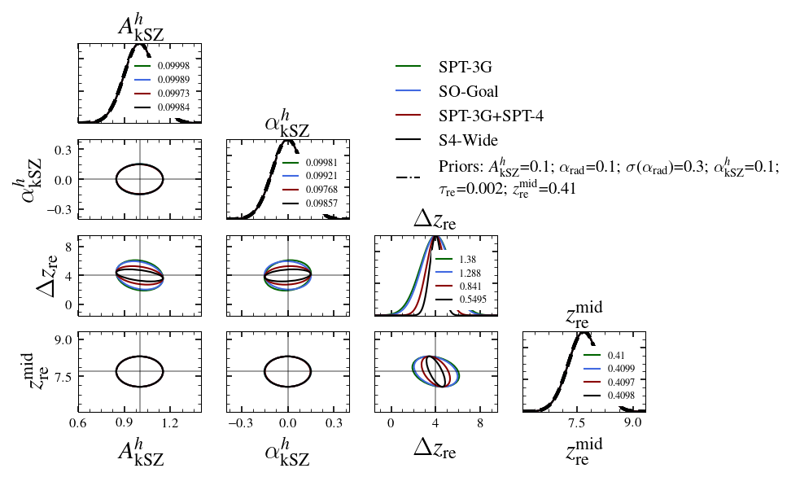

```python
constrain_reion = True
if constrain_reion: #20230405
    prior_dic = {'tau':0.007,
                 'alpha_radio': spec_index_radio_prior,
                 'alpha_radio_sigma': spec_index_radio_scatter_prior,
                 'Aksz_h': 0.1,
                 'alphaksz_h': 0.1,
                }
    import fisher_tools, tools_for_plotting
    fisher_opfname = 'publish/fisher/F_mat_results_reion.npy'
    fix_params = ['mnu', 'ws', 'neff', 'Acibtsz']#, 'zmid', 'zdur',]#'Aksz_h', 'alphaksz_h']
    reqd_ilcname = 'cross-ILC'
    reqd_lmax = 5000
    reqd_lmax_ksz = 5000
    #reqd_expname_arr = ['spt4', 's4_wide']
    #reqd_expname_arr = expname_arr
    reqd_expname_arr = ['spt3g', 'so_goal', 'spt4', 's4_wide']
    color_arr = ['darkgreen', 'royalblue', 'darkred', 'black']
    fisher_keyname = (reqd_lmax_ksz, reqd_lmax)
    parent_F_dic = np.load(fisher_opfname, allow_pickle=True).item()['lmax_%s' %(reqd_lmax)]
    tmp_F_mat, param_names = parent_F_dic['s4_wide'][reqd_ilcname][fisher_keyname]

    param_dict = tools_for_plotting.get_ini_param_dict()
    for p in param_names:
        if p not in param_dict:
            param_dict['%s' %(p)] = eval(p)

    param_names_ori = np.copy(param_names)
    ###print(param_names_ori); sys.exit()

    planck_prior_dic = {'ombh2': 0.00015, 'omch2': 0.0012, 'As': 2.9063421874997835e-11, 'ns':  0.0042, 'thetastar':0.00031/100.}
    prior_dic_mod = {}
    ##for ppp in planck_prior_dic:
    ##    prior_dic_mod[ppp] = planck_prior_dic[ppp]
    for ppp in prior_dic:
        prior_dic_mod[ppp] = prior_dic[ppp]
    prior_dic_mod['tau']=0.007 ##0.007 ##2
    prior_name = r'$\sigma(\tau)_{\rm Planck}$'
    if (1):
        prior_dic_mod['tau']=0.002 #0.007 ##2
        prior_name = r'$\sigma(\tau)_{\rm LiteBIRD}$'
    ##print(prior_dic_mod); sys.exit()

    if (1): #convert tau prior to zmind prior
        zmid_low = camb.get_zre_from_tau(pars,param_dict['tau'] - prior_dic_mod['tau'])
        zmid_high = camb.get_zre_from_tau(pars,param_dict['tau'] + prior_dic_mod['tau'])
        zmid_range = zmid_high - zmid_low
        zmid_range = round(zmid_range, 2)
        #print( zmid, zmid_low, zmid_high, zmid_range )
        prior_dic_mod['zmid'] = zmid_range

    ##print(prior_dic_mod); sys.exit()
    fix_params_mod = np.copy(fix_params).tolist()
    #print(fix_params_mod, prior_dic_mod); sys.exit()
    #fix_params_mod.append('Aksz_h')
    #fix_params_mod.append('alphaksz_h')
    #fix_params_mod.append('zmid')

    import tools_for_plotting
    desired_params_to_plot = ['Aksz_h', 'alphaksz_h', 'zdur', 'zmid']
    #desired_params_to_plot = ['zmid', 'zdur']
    ###print(desired_params_to_plot)
    for ppp in desired_params_to_plot:
        ###print(ppp)
        if ppp in fix_params_mod:
            desired_params_to_plot.remove(ppp)

    ###print(desired_params_to_plot); sys.exit()

    #desired_params_to_plot = ['zdur', 'omch2']
    #desired_params_to_plot = ['zmid', 'zdur']
    #colorarr = ['orangered', 'darkgreen']
    color_dic = {}
    F_dic = {}
    reqd_expname_str_arr = []
    for cntr, expname in enumerate( reqd_expname_arr ):

        F_mat_mod, param_names_ori = parent_F_dic[expname][reqd_ilcname][fisher_keyname]

        #add priors.
        F_mat_mod = fisher_tools.add_priors(F_mat_mod, param_names_ori, prior_dic_mod)
        print('\t\tPriors set.')

        #fix desired parameters.
        F_mat_mod, param_names_mod = fisher_tools.fix_params(F_mat_mod, param_names_ori, fix_params_mod)
        print('\t\tUndesired parameters (%s) fixed.' %(fix_params))

        expname_str = exp_specs_dict[expname][0]

        F_dic[expname_str] = F_mat_mod
        #color_dic[expname_str] = [exp_specs_dict[expname][2]]
        color_dic[expname_str] = [color_arr[cntr]]
        color_dic[expname] = [color_arr[cntr]]
        reqd_expname_str_arr.append( expname_str )

    if (1):
        tr, tc = tools_for_plotting.make_triangle_plot(reqd_expname_str_arr, F_dic, param_dict, param_names_mod, desired_params_to_plot, color_dic, ls_dic = None, one_or_two_sigma = 1, fsval = 11, prior_dic = prior_dic_mod)

        if tr > 2:
            ax = subplot(tr, tc, 3)
        else:
            ax = subplot(tr, tc, 2)
        for tmpnamecntr, expname in enumerate( reqd_expname_arr ):
            plot([], [], color = color_dic[expname][0], label = r'%s' %(exp_specs_dict[expname][0]))

        prior_str = ''
        total_priors = 0
        for ppp in sorted(prior_dic_mod):
            if ppp not in param_names_mod: continue
            #prior_str = '%s; $\sigma$(%s)=%s' %(prior_str, tools_for_plotting.get_latex_param_str(ppp), prior_dic_mod[ppp])
            if total_priors>3:
                prior_str = '%s;\n%s=%g' %(prior_str, tools_for_plotting.get_latex_param_str(ppp), prior_dic_mod[ppp])
                total_priors =0
            else:
                prior_str = '%s; %s=%g' %(prior_str, tools_for_plotting.get_latex_param_str(ppp), prior_dic_mod[ppp])
            total_priors += 1
        prior_str = prior_str.strip('; ')
        plot([], [], 'k-.', label = r'Priors: %s' %(prior_str))
        legend(loc = 2, fontsize = 10, framealpha = 0.)
        axis('off')

    else:
        #desired_params_to_plot = ['Aksz_h', 'alphaksz_h', 'zdur', 'zmid']
        desired_params_to_plot = ['zdur', 'zmid']
        fix_axis_range_to_xxsigma = None #3.
        #tr, tc = tools_for_plotting.make_triangle_plot(reqd_expname_arr, F_dic, param_dict, param_names_mod, desired_params_to_plot, color_dic, ls_dic = None, one_or_two_sigma = 1, fix_axis_range_to_xxsigma = fix_axis_range_to_xxsigma, fsval = 11, prior_dic = prior_dic_mod, show_diagonal = False)
        tools_for_plotting.show_two_parameter_plot(reqd_expname_str_arr, F_dic, param_dict, param_names_mod, desired_params_to_plot, color_dic, ls_dic = None, one_or_two_sigma = 1, fsval = 12, fix_axis_range_to_xxsigma = fix_axis_range_to_xxsigma, lwval = 1.5, prior_dic = prior_dic_mod, prior_name = prior_name)
        show()
```

```python
def get_bias_vector_v1(els, F_mat, param_names, delta_cl_dic, cl_deriv_dic, cl_sys_dic, max_l = 5000):
    bias_vector = []
    for pcntr, p in enumerate( param_names ):
        curr_bias_vector = []
        for l in range(max_l):
            TT, EE, TE = delta_cl_dic['TT'][l], delta_cl_dic['EE'][l], delta_cl_dic['TE'][l]
            TT_der, EE_der, TE_der = cl_deriv_dic[p]['TT'][l], cl_deriv_dic[p]['EE'][l], cl_deriv_dic[p]['TE'][l]

            curr_fisher_cov = fisher_tools.get_cov(TT, EE, TE)
            #print(curr_fisher_cov); sys.exit()
            inv_curr_fisher_cov = fisher_tools.get_fisher_inv(curr_fisher_cov)

            TT_sys, EE_sys, TE_sys = cl_sys_dic['TT'][l], cl_sys_dic['EE'][l], cl_sys_dic['TE'][l]
            sysres_vec = fisher_tools.get_cov(TT_sys, EE_sys, TE_sys)
            der_vec = fisher_tools.get_cov(TT_der, EE_der, TE_der)
            curr_bias_val_with_trace = np.trace( np.dot( np.dot(inv_curr_fisher_cov, sysres_vec), np.dot(inv_curr_fisher_cov, der_vec) ) )
            ##print(curr_bias_val_with_trace); sys.exit()

            curr_bias_vector.append( curr_bias_val_with_trace )
        bias_vector.append( np.sum(curr_bias_vector) )
        ##print('\t\t%s, %s' %(p, bias_vector[pcntr]))

    bias_vector = np.asarray(bias_vector)
    C_mat = np.linalg.inv(F_mat)
    final_bias_vector = np.asarray( np.dot( np.mat(bias_vector), C_mat ) )[0]

    return final_bias_vector

#include systematic error for CIB + tSZ signals.
total_ksz_fisher_fname = 'publish/fisher/F_mat_results_totalksz.npy'
cib_tsz_res_sys = 0.05
reqd_lmax_tt = 5000
maxltempkeyname = 'lmax_%s' %(reqd_lmax_tt)
reqd_F_dic = np.load(total_ksz_fisher_fname, allow_pickle=True).item()[maxltempkeyname]
reqd_lmax_tt_ksz_arr = [3000, 3500, 4000, 4500, 5000]
desired_param = 'Aksz'
fix_params_arr = ['mnu', 'ws', 'neff', 'alpha_radio', 'alpha_radio_sigma', 'Acibtsz']
prior_dic = {'tau':0.007}# #Planck tau prior
#ilcname_arr = ['MV', 'cross-ILC']
ilcname_arr = ['cross-ILC']
debug = False ##True #False ##True
bias_dic_for_plotting = {}
for expname in reqd_F_dic:
    bias_dic_for_plotting[expname] = {}
    if debug and expname != 's4_wide': continue
    print('\nExperiment = %s' %(expname))
    latex_str = ''
    for ilcname in ilcname_arr:
        bias_dic_for_plotting[expname][ilcname] = {}
        if debug:
            clf()
            ax = subplot(111, yscale = 'log')
        for tmplmaxcntr, reqd_lmax_tt_ksz in enumerate( reqd_lmax_tt_ksz_arr ):
            keyname = (reqd_lmax_tt_ksz, reqd_lmax_tt)
            if keyname not in reqd_F_dic[expname][ilcname]: continue

            #Fisher matrix.
            tmp_F_mat, tmp_param_names = reqd_F_dic[expname][ilcname][keyname]

            #add priors.
            tmp_F_mat = fisher_tools.add_priors(tmp_F_mat, tmp_param_names, prior_dic)

            #fix desired parameters.
            tmp_F_mat, tmp_param_names = fisher_tools.fix_params(tmp_F_mat, tmp_param_names, fix_params_arr)

            if (1): #bias related stuff
                cl_dic_forthisexp = copy.deepcopy(cl_dic_ori)
                cl_deriv_dic_forthisexp = copy.deepcopy(cl_deriv_dic_ori)

                #get experiment-dependent CIB+tSZ stuffs
                if ilcname == 'MV':
                    curr_reqd_ilc_keyname_1 = 'mv'
                    curr_reqd_ilc_keyname_2 = 'mv'
                else:
                    curr_reqd_ilc_keyname_1 = reqd_ilc_keyname_1
                    curr_reqd_ilc_keyname_2 = reqd_ilc_keyname_2
                cl_cib_tsz, cl_dic_forthisexp, cl_deriv_dic_forthisexp = get_cib_tsz_spectrum_and_derivatives(expname, cl_dic_forthisexp, cl_deriv_dic_forthisexp,
                                                                                                              curr_reqd_ilc_keyname_1, reqd_ilc_keyname_2 = curr_reqd_ilc_keyname_2,
                                                                                                              Acibtsz = Acibtsz, Acibtsz_step = Acibtsz_step)

                if (0):##ilcname == 'MV':
                    cl_cib_tsz = 3./dl_fac**0.7 #remove me

                cl_deriv_dic_forthisexp['Aksz']['TT'][reqd_lmax_tt_ksz:] = 0.
                ##cl_cib_tsz[:2500] = 0.
                cl_cib_tsz[reqd_lmax_tt_ksz:] = 0.
                cl_sys_dic = {}
                cl_sys_dic['TT'] = cl_cib_tsz * cib_tsz_res_sys
                cl_sys_dic['EE'] = np.zeros_like(cl_cib_tsz)
                cl_sys_dic['TE'] = np.zeros_like(cl_cib_tsz)


                bands = get_exp_bands(expname)

                #get MV polarisation ILC residuals
                els, mvilc_pol_residuals = get_polarisation_mvilc_residuals(expname)
                dl_fac = els * (els+1)/2/np.pi

                #get temperature ILC residuals
                els, total_ilc_residual_mv, total_ilc_residual_1, total_ilc_residual_2, total_ilc_residual_12 = get_temperature_ilc_residuals(expname, curr_reqd_ilc_keyname_1, curr_reqd_ilc_keyname_2, quiet = True)

                cl_dic_mod = {}
                for which_spec in cl_dic:
                    cl_dic_mod[which_spec] = cl_dic[which_spec] - cl_sys_dic[which_spec]

                expname_str, fsky, colorval = exp_specs_dict[expname]
                delta_cl_dic, delta_cl_dic_mv = wrapper_get_delta_cl(els, cl_dic_mod, fsky,
                                        total_ilc_residual_1, total_ilc_residual_2, total_ilc_residual_12,
                                        total_ilc_residual_mv, mvilc_pol_residuals,
                                       )

                ##print(delta_cl_dic, delta_cl_dic_mv); sys.exit()

                if debug:#reqd_lmax_tt_ksz == 5000:
                    plot(els, dl_fac * cl_sys_dic['TT'])
                    plot(els, dl_fac * -cl_sys_dic['TT'], alpha = 0.2)
                    axhline(3., lw = 1.)
                    xlim(0., 5000.); ylim(.01, 20.); title(r'%s' %(ilcname))

                final_bias_vector = fisher_tools.get_bias_vector(els, tmp_F_mat, tmp_param_names, delta_cl_dic, cl_deriv_dic_forthisexp, cl_sys_dic)

            pind = np.where(tmp_param_names == desired_param)
            sys_sigma_Aksz = final_bias_vector[pind]
            sigma_Aksz = fisher_tools.get_sigma_of_a_parameter(tmp_F_mat, tmp_param_names, desired_param, prior_dic = prior_dic, fix_params_arr = fix_params_arr)
            Aksz_bias_over_error = sys_sigma_Aksz / sigma_Aksz
            ##print(tmp_F_mat.shape, tmp_param_names, sigma_Aksz)
            snr_Aksz = Aksz/sigma_Aksz
            print( '\t\tILC=%s; lmax=%s; SNR=%.2f; sigma=%.3f; Bias=%.3f; Bias/sigma=%.2f' %(ilcname, reqd_lmax_tt_ksz, snr_Aksz, sigma_Aksz, sys_sigma_Aksz, Aksz_bias_over_error) )
            bias_dic_for_plotting[expname][ilcname][reqd_lmax_tt_ksz] = [snr_Aksz, sigma_Aksz, sys_sigma_Aksz, Aksz_bias_over_error]
            latex_str = '%s & %.2f' %(latex_str, snr_Aksz); #sys.exit()
        if debug: show(); #sys.exit()
    ##print('\t', latex_str);
    ###sys.exit()

sys.exit()
```

```
Experiment = spt3g
		ILC=cross-ILC; lmax=3000; SNR=8.86; sigma=0.113; Bias=-0.015; Bias/sigma=-0.13
```

[output not shown]

```python
exp_specs_dict = {
                  's4_wide': ['S4-Wide', 0.57, 'black'],
                  #'s4_wide_withccatp': ['S4-Wide + FYST', 0.57],
                  's4_deep': ['S4-Ultra Deep', 0.03, 'darkred'],
                  'spt3g': ['SPT-3G', 0.03, 'darkgreen'],
                  'spt4': ['SPT-3G+SPT-4', 0.03, 'lightgreen'],
                  'so_baseline': ['SO-Baseline', 0.4, 'royalblue'],
                  'so_baseline_withccatp': ['SO-Baseline + FYST', 0.4, 'lightskyblue'],
                  'so_goal': ['SO-Goal', 0.4, 'darkorange'],
                  'so_goal_withccatp': ['SO-Goal + FYST', 0.4, '#F4CEA7'],
                  }

reqd_lmax_tt_ksz_arr = [3000, 3500, 4000, 4500, 5000]
clf()
fsval = 14
barhwval = 0.5
single_row = False
if single_row:
    fig = figure(figsize = (14, 3.4))
    subplots_adjust(wspace=0.05)
    tr, tc = 1, len(bias_dic_for_plotting)
    exparr_sorted_for_plotting = list(bias_dic_for_plotting.keys())
else:
    fig = figure(figsize = (12., 6.5))
    subplots_adjust(wspace=0.1, hspace=0.3)
    tr, tc = 2, len(bias_dic_for_plotting)/2
    exparr_sorted_for_plotting = ['spt3g', 'so_baseline', 'so_goal', 's4_wide', 'spt4', 'so_baseline_withccatp', 'so_goal_withccatp', 's4_deep']

for expcntr, expname in enumerate( exparr_sorted_for_plotting ):
    ax = subplot(tr, tc, expcntr+1)
    yloc = 0
    for lmaxcntr, reqd_lmax_tt_ksz in enumerate( reqd_lmax_tt_ksz_arr ):
        for ilcname in bias_dic_for_plotting[expname]:
            snr_Aksz, sigma_Aksz, sys_sigma_Aksz, Aksz_bias_over_error = bias_dic_for_plotting[expname][ilcname][reqd_lmax_tt_ksz]
            if ilcname == 'MV':
                hatchstyle = 'xxxx'
            else:
                hatchstyle = None
            expname_str, fskyval, colorval = exp_specs_dict[expname]
            barh(yloc+barhwval/2, abs(Aksz_bias_over_error), color = colorval, height = barhwval, hatch = hatchstyle, edgecolor = 'white')
            yloc+=barhwval
        #if reqd_lmax_tt_ksz != reqd_lmax_tt_ksz_arr[-1]: axhline(yloc-0.5, lw = 2.)
        if lmaxcntr%2==0:
            axhspan(yloc-(2*barhwval), yloc, color='lightgray', alpha = 0.3, zorder = -1000.)
    if single_row:
        write_xlab = True
    else:
        if expcntr>=tc:
            write_xlab = True
        else:
            write_xlab = False
    if write_xlab:
        xlabel(r'Bias/Error', fontsize = fsval)
    setp(ax.get_yticklabels(), visible=False); tick_params(axis='y', which='both', left=False, right = False)
    if single_row:
        if expcntr==0:
            write_ylab = True
        else:
            write_ylab = False
    else:
        if expcntr%tc==0:
            write_ylab = True
        else:
            write_ylab = False
    if write_ylab:
        tick_params(axis='y', which='both', left=False, right = False)
        if single_row:
            xloc = -3.
        else:
            xloc = -2.
        yloc = 0
        for lmaxcntr, reqd_lmax_tt_ksz in enumerate( reqd_lmax_tt_ksz_arr ):
            for ilcname in bias_dic_for_plotting[expname]:
                if ilcname == 'MV':
                    text(xloc, yloc+0.4, r'$\ell_{\rm max} = $%s' %(reqd_lmax_tt_ksz), fontsize = fsval-1)#, rotation = 20.)
                yloc+=barhwval

    title(r'%s' %(expname_str), fontsize = fsval)
    ylim(0., yloc)
    xlim(0., 5.)

if (1): #legend
    xloc, yloc = 0.1, 0.
    w, h = 0.8, 0.05
    cax = fig.add_axes([xloc, yloc, w, h])
    barh(0., 0., color = 'black', hatch = 'xxxx', edgecolor = 'white', label = r'MV')
    barh(0., 0., color = 'black', hatch = None, label = r'Cross-ILC')
    legend(loc = 2, fontsize=fsval+10, ncol=2, framealpha = 0., columnspacing=0.5)
    axis('off')
show()
sys.exit()
```

[output not shown]

```python
#check Fisher bias
if (1):
    #CMB stuffs
    #get fiducual LCDM power spectra computed using CAMB
    print('get fiducual LCDM power spectra computed using CAMB')
    camb_fname = '%s/cmb_spectra_%s.txt' %(camb_folder, which_spectra)
    cl_camb = np.loadtxt(camb_fname)
    el_camb = cl_camb[:,0]
    cl_camb_tt = cl_camb[:,1]
    dl_fac_camb = el_camb * (el_camb+1)/2/np.pi
    cl_dic = {}
    cl_dic['TT'] = cl_camb[:,1]
    cl_dic['EE'] = cl_camb[:,2]
    cl_dic['TE'] = cl_camb[:,3]

    #get derivatives of CMB power spectrum for different LCDM parameters.
    #They are already computed and stored.
    print('get/read derivatives')
    camb_deriv_fname = '%s/cmb_spectra_derivs_%s.npy' %(camb_folder, which_spectra)
    cl_deriv_dic_tmp = np.load(camb_deriv_fname, allow_pickle = 1).item()
    cl_deriv_dic = {}
    param_names = []
    for p in sorted( cl_deriv_dic_tmp ):
        if p == 'ell': continue
        cl_deriv_dic[p]={}
        if planck_cosmo_version == 2018:
            cl_deriv_dic[p]['TT'] = cl_deriv_dic_tmp[p]['TT']
            cl_deriv_dic[p]['EE'] = cl_deriv_dic_tmp[p]['EE']
            cl_deriv_dic[p]['TE'] = cl_deriv_dic_tmp[p]['TE']
        else:
            cl_deriv_dic[p]['TT'] = cl_deriv_dic_tmp[p][0]
            cl_deriv_dic[p]['EE'] = cl_deriv_dic_tmp[p][1]
            cl_deriv_dic[p]['TE'] = cl_deriv_dic_tmp[p][2]

        if p == 'As' and planck_cosmo_version == 2015:
            cl_deriv_dic[p]['TT'] *= 1e9
            cl_deriv_dic[p]['EE'] *= 1e9
            cl_deriv_dic[p]['TE'] *= 1e9

        param_names.append( p )

    #interpolate CAMB spectra / derivatives on the desired els.
    for which_spec in cl_dic:
        cl_dic[which_spec] = np.interp(els, el_camb, cl_dic[which_spec], right=0.)
    for p in sorted( param_names ):
        for which_spec in cl_deriv_dic[p]:
            cl_deriv_dic[p][which_spec] = np.interp(els, el_camb, cl_deriv_dic[p][which_spec], right=0.)

    cl_dic_cmb = copy.deepcopy(cl_dic)

expname = 's4_wide'
fix_params = ['mnu', 'ws', 'neff', 'Acibtsz', 'Aksz', 'alpha_radio', 'alpha_radio_sigma']
prior_dic = {}
prior_dic['tau'] = 0.007
reqd_ilcname = 'MV' #'cross-ILC'
reqd_lmax = 5000
reqd_lmax_ksz = 5000
fisher_keyname = (reqd_lmax_ksz, reqd_lmax)

sys_bias_param_name = 'omch2' #neff'
sys_bias_spectra_to_be_shifted = 'TT'
sys_bias_shift_interms_of_simga = 1.

'''
parent_F_dic = np.load(fisher_opfname, allow_pickle=True).item()['lmax_%s' %(reqd_lmax)]
F_mat, param_names = parent_F_dic[expname][reqd_ilcname][fisher_keyname]
if (1): #remove me later
    fix_params = np.copy( param_names ).tolist()
    fix_params.remove( sys_bias_param_name )
    #fix_params.remove( 'ns' )
    #fix_params.remove( 'omch2' )

F_mat_mod = np.copy( F_mat )
param_names_mod = np.copy( param_names )

stat_sigma = fisher_tools.get_sigma_of_a_parameter(F_mat_mod, param_names_mod, sys_bias_param_name, prior_dic = prior_dic, fix_params_arr = fix_params)
print(stat_sigma, param_dict[sys_bias_param_name], (param_dict[sys_bias_param_name]/stat_sigma)); #sys.exit()
'''

#stuff for bias calc.
cl_dic_forthisexp = copy.deepcopy(cl_dic_cmb)
cl_deriv_dic_forthisexp = copy.deepcopy(cl_deriv_dic)

#get MV polarisation ILC residuals
els, mvilc_pol_residuals = get_polarisation_mvilc_residuals(expname)
dl_fac = els * (els+1)/2/np.pi

#get temperature ILC residuals
curr_reqd_ilc_keyname_1, curr_reqd_ilc_keyname_2 = 'mv', 'mv'
els, total_ilc_residual_mv, total_ilc_residual_1, total_ilc_residual_2, total_ilc_residual_12 = get_temperature_ilc_residuals(expname, curr_reqd_ilc_keyname_1, curr_reqd_ilc_keyname_2, quiet = True)
#print(curr_reqd_ilc_keyname_1, curr_reqd_ilc_keyname_2)

expname_str, fsky, colorval = exp_specs_dict[expname]
delta_cl_dic, delta_cl_dic_mv = wrapper_get_delta_cl(els, cl_dic_forthisexp, fsky,
                        total_ilc_residual_1, total_ilc_residual_2, total_ilc_residual_12,
                        total_ilc_residual_mv, mvilc_pol_residuals,
                       )

if (1): #get Fisher matrix first
    min_l_pol, max_l_pol = 30, 5000
    min_l_temp, max_l_temp = 30, 5000 #we will set different ell ranges for kSZ. Check max_l_temp_for_ksz_arr below.
    pspectra_to_use = ['TT', 'EE', 'TE']
    param_names = list(cl_deriv_dic_forthisexp.keys())
    F_mat = fisher_tools.get_fisher_matrix(els, cl_deriv_dic_forthisexp, delta_cl_dic, param_names, pspectra_to_use = pspectra_to_use,\
                min_l_temp = min_l_temp, max_l_temp = max_l_temp, min_l_pol = min_l_pol, max_l_pol = max_l_pol)

    F_mat_mod = np.copy( F_mat )
    param_names_mod = np.copy( param_names )

    F_mat_mod = fisher_tools.add_priors(F_mat_mod, param_names_mod, prior_dic)
    F_mat_mod, param_names_mod = fisher_tools.fix_params(F_mat_mod, param_names_mod, fix_params)

if (1): #introduce systematic shift
    stat_sigma = fisher_tools.get_sigma_of_a_parameter(F_mat_mod, param_names_mod, sys_bias_param_name, prior_dic = prior_dic, fix_params_arr = fix_params)
    print(sys_bias_param_name, stat_sigma, param_dict[sys_bias_param_name], (param_dict[sys_bias_param_name]/stat_sigma)); #sys.exit()

    sys_bias_param_shift = param_dict[sys_bias_param_name] + ( stat_sigma * sys_bias_shift_interms_of_simga )
    els_sys, cl_sys_shift, sys_bias_spectra_to_be_shifted = fisher_tools.simple_fisher_bias_check_introduce_sys_by_changing_cosmo_params(sys_bias_param_name, sys_bias_param_shift = sys_bias_param_shift, sys_bias_spectra_to_be_shifted = sys_bias_spectra_to_be_shifted)
    cl_sys_shift = np.interp(els, els_sys, cl_sys_shift)
    #cl_sys_shift = cl_sys_shift * 0.

    cl_sys_dic = {}
    for which_spec in cl_dic:
        if which_spec == sys_bias_spectra_to_be_shifted:
            cl_sys_dic[which_spec] = cl_sys_shift
        else:
            cl_sys_dic[which_spec] = np.zeros_like(cl_sys_shift)

if (1): #get modified cl_dic and delta_cl_dic
    cl_dic_mod = {}
    for which_spec in cl_dic:
        cl_dic_mod[which_spec] = cl_dic[which_spec] - cl_sys_dic[which_spec]

    expname_str, fsky, colorval = exp_specs_dict[expname]
    delta_cl_dic, delta_cl_dic_mv = wrapper_get_delta_cl(els, cl_dic_mod, fsky,
                            total_ilc_residual_1, total_ilc_residual_2, total_ilc_residual_12,
                            total_ilc_residual_mv, mvilc_pol_residuals,
                           )


final_bias_vector = fisher_tools.get_bias_vector(els, F_mat_mod, param_names_mod, delta_cl_dic, cl_deriv_dic_forthisexp, cl_sys_dic)
print('Bias vector = %s' %(final_bias_vector))

pind = np.where(param_names_mod == sys_bias_param_name)
sys_sigma = final_bias_vector[pind][0]
stat_sigma = fisher_tools.get_sigma_of_a_parameter(F_mat_mod, param_names_mod, sys_bias_param_name)
bias_over_error = sys_sigma / stat_sigma
print('param = %s; Fid = %s; Shifted = %.5f; recovered = %.5f; stat sigma = %.3f, Bias / error = %.3f'
      %(sys_bias_param_name, param_dict[sys_bias_param_name],
    sys_bias_param_shift-param_dict[sys_bias_param_name], sys_sigma, stat_sigma, bias_over_error))
sys.exit()
print(stat_sigma)
bias_over_error = sys_sigma / stat_sigma
snr = param_dict[sys_bias_param_name]/stat_sigma
print( '\t\tSNR=%.2f; sigma=%.3f; Bias=%.3f; Bias/sigma=%.2f' %(snr, stat_sigma, sys_sigma, bias_over_error) )

if (1):#debug:#reqd_lmax_tt_ksz == 5000:
    clf()
    ax = subplot(111, yscale='log')
    plot(els, dl_fac * cl_dic['TT'])
    plot(els, dl_fac * cl_dic_mod['TT'], color = 'green')
    plot(els, dl_fac * cl_sys_shift, color = 'red')
    plot(els, dl_fac * -cl_sys_shift, color = 'red', ls = '-.')
    axhline(3., lw = 1.)
    xlim(0., 5000.); ylim(1e-3, 7e3);
    show(); sys.exit()
```

```
get fiducual LCDM power spectra computed using CAMB
get/read derivatives
omch2 0.0004005848157975189 0.12 299.56202848351506
Bias vector = [ 2.04861489e-14  2.13468037e-05 -4.49686909e-07  1.65601634e-05
  1.08194905e-05 -2.77212202e-09]
param = omch2; Fid = 0.12; Shifted = 0.00040; recovered = 0.00002; stat sigma = 0.000, Bias / error = 0.038
```

```
An exception has occurred, use %tb to see the full traceback.

SystemExit
```

```python
param_names_mod
```

```
array(dict_keys(['As', 'mnu', 'neff', 'ns', 'ombh2', 'omch2', 'tau', 'thetastar', 'ws']),
      dtype=object)
```

# Print total kSZ SNR for the paper.

## Priors: $\sigma(\tau) = 0.007$ (${\it Planck}$-like).

## Parameters fixed: $\theta \in [\sum m_{\nu}, w_{0}, N_{\rm eff}, \alpha_{\rm rad}, \sigma(\alpha_{\rm rad})]$

```python
total_ksz_fisher_fname = 'publish/data/F_mat_results_totalksz.npy'
reqd_lmax_tt = 5000
maxltempkeyname = 'lmax_%s' %(reqd_lmax_tt)
reqd_F_dic = np.load(total_ksz_fisher_fname, allow_pickle=True).item()[maxltempkeyname]
reqd_lmax_tt_ksz_arr = [3000, 3500, 4000, 4500, 5000]
desired_param = 'Aksz'
fix_params_arr = ['mnu', 'ws', 'neff', 'alpha_radio', 'alpha_radio_sigma']
prior_dic = {'tau':0.007}# #Planck tau prior
ilcname_arr = ['MV', 'cross-ILC']
for expname in reqd_F_dic:
    print('\nExperiment = %s' %(expname))
    latex_str = ''
    for ilcname in ilcname_arr:
        for reqd_lmax_tt_ksz in reqd_lmax_tt_ksz_arr:
            keyname = (reqd_lmax_tt_ksz, reqd_lmax_tt)
            if keyname not in reqd_F_dic[expname][ilcname]: continue
            tmp_F_mat, tmp_param_names = reqd_F_dic[expname][ilcname][keyname]
            sigma_Aksz = fisher_tools.get_sigma_of_a_parameter(tmp_F_mat, tmp_param_names, desired_param, prior_dic = prior_dic, fix_params_arr = fix_params_arr)
            ##print(tmp_F_mat.shape, tmp_param_names, sigma_Aksz)
            snr_Aksz = Aksz/sigma_Aksz
            print( '\t\tILC = %s; lmax for kSZ = %s; AkSZ SNR = %.2f' %(ilcname, reqd_lmax_tt_ksz, snr_Aksz) )
            latex_str = '%s & %.2f' %(latex_str, snr_Aksz); #sys.exit()
    print('\t', latex_str); ##sys.exit()

sys.exit()
```

```
Experiment = spt3g
		ILC = MV; lmax for kSZ = 3000; AkSZ SNR = 11.04
		ILC = cross-ILC; lmax for kSZ = 3000; AkSZ SNR = 8.86
		ILC = cross-ILC; lmax for kSZ = 3500; AkSZ SNR = 13.78
		ILC = cross-ILC; lmax for kSZ = 4000; AkSZ SNR = 17.41
		ILC = cross-ILC; lmax for kSZ = 4500; AkSZ SNR = 19.90
		ILC = cross-ILC; lmax for kSZ = 5000; AkSZ SNR = 21.61
	  & 11.04 & 8.86 & 13.78 & 17.41 & 19.90 & 21.61

Experiment = spt4
		ILC = MV; lmax for kSZ = 3000; AkSZ SNR = 12.45
		ILC = cross-ILC; lmax for kSZ = 3000; AkSZ SNR = 11.79
		ILC = cross-ILC; lmax for kSZ = 3500; AkSZ SNR = 22.71
		ILC = cross-ILC; lmax for kSZ = 4000; AkSZ SNR = 32.16
		ILC = cross-ILC; lmax for kSZ = 4500; AkSZ SNR = 38.27
		ILC = cross-ILC; lmax for kSZ = 5000; AkSZ SNR = 42.72
	  & 12.45 & 11.79 & 22.71 & 32.16 & 38.27 & 42.72

Experiment = so_baseline
		ILC = MV; lmax for kSZ = 3000; AkSZ SNR = 16.07
		ILC = cross-ILC; lmax for kSZ = 3000; AkSZ SNR = 5.17
		ILC = cross-ILC; lmax for kSZ = 3500; AkSZ SNR = 7.94
		ILC = cross-ILC; lmax for kSZ = 4000; AkSZ SNR = 10.80
		ILC = cross-ILC; lmax for kSZ = 4500; AkSZ SNR = 13.21
		ILC = cross-ILC; lmax for kSZ = 5000; AkSZ SNR = 15.04
	  & 16.07 & 5.17 & 7.94 & 10.80 & 13.21 & 15.04

Experiment = so_baseline_withccatp
		ILC = MV; lmax for kSZ = 3000; AkSZ SNR = 16.14
		ILC = cross-ILC; lmax for kSZ = 3000; AkSZ SNR = 7.41
		ILC = cross-ILC; lmax for kSZ = 3500; AkSZ SNR = 11.68
		ILC = cross-ILC; lmax for kSZ = 4000; AkSZ SNR = 16.09
		ILC = cross-ILC; lmax for kSZ = 4500; AkSZ SNR = 19.84
		ILC = cross-ILC; lmax for kSZ = 5000; AkSZ SNR = 22.87
	  & 16.14 & 7.41 & 11.68 & 16.09 & 19.84 & 22.87

Experiment = so_goal
		ILC = MV; lmax for kSZ = 3000; AkSZ SNR = 17.03
		ILC = cross-ILC; lmax for kSZ = 3000; AkSZ SNR = 5.50
		ILC = cross-ILC; lmax for kSZ = 3500; AkSZ SNR = 8.61
```

[output cut: 16 more lines]

```
		ILC = cross-ILC; lmax for kSZ = 3000; AkSZ SNR = 39.51
		ILC = cross-ILC; lmax for kSZ = 3500; AkSZ SNR = 64.55
		ILC = cross-ILC; lmax for kSZ = 4000; AkSZ SNR = 84.78
		ILC = cross-ILC; lmax for kSZ = 4500; AkSZ SNR = 99.30
		ILC = cross-ILC; lmax for kSZ = 5000; AkSZ SNR = 109.61
	  & 47.46 & 39.51 & 64.55 & 84.78 & 99.30 & 109.61

Experiment = s4_deep
		ILC = MV; lmax for kSZ = 3000; AkSZ SNR = 14.16
		ILC = cross-ILC; lmax for kSZ = 3000; AkSZ SNR = 13.60
		ILC = cross-ILC; lmax for kSZ = 3500; AkSZ SNR = 30.53
		ILC = cross-ILC; lmax for kSZ = 4000; AkSZ SNR = 49.36
		ILC = cross-ILC; lmax for kSZ = 4500; AkSZ SNR = 62.16
		ILC = cross-ILC; lmax for kSZ = 5000; AkSZ SNR = 70.46
	  & 14.16 & 13.60 & 30.53 & 49.36 & 62.16 & 70.46
```

```
An exception has occurred, use %tb to see the full traceback.

SystemExit
```

```python
#parameters for constraining/fixing, power spectra to be used, \ell ranges and priors.
pspectra_to_use = ['TT', 'EE', 'TE']
min_l_pol, max_l_pol = 30, 5000
min_l_temp, max_l_temp = 30, 5000 #we will set different ell ranges for kSZ. Check max_l_temp_for_ksz_arr below.
prior_dic = {'tau':0.007, #Planck tau prior
             'alpha_radio': spec_index_radio_prior,
             'alpha_radio_sigma': spec_index_radio_scatter_prior,
             'Aksz_h': 0.1,
             'alphaksz_h': 0.1,
             'Acibtsz': 0.0001
                }#, 'Akszh': dl_ksz_amp_homo/10.}#02}#02}

expname_arr = ['spt3g', 'spt4', 'so_baseline', 'so_baseline_withccatp', 'so_goal', 'so_goal_withccatp', 's4_wide', 's4_deep']
#expname_arr = ['so_baseline', 'so_baseline_withccatp', 'so_goal', 'so_goal_withccatp']
#expname_arr = ['s4_wide', 'spt4']

parent_F_dic = {}
for iter in range(1):
    print('\n\n')
    print('#######################')
    if iter == 0: #fix radio
        fix_params = ['mnu', 'ws', 'neff', 'alpha_radio', 'alpha_radio_sigma']#, 'zmid', 'zdur',]#'Aksz_h', 'alphaksz_h']
        print('Iter = %s: Fixing radio' %(iter))
    else: #marginalise over radio
        fix_params = ['mnu', 'ws', 'neff']
        print('Iter = %s: Marginalise over radio' %(iter))
    print('#######################')

    parent_F_dic[iter] = {}
    for expname in expname_arr:
        parent_F_dic[iter][expname] = {}

        cl_dic_forthisexp = copy.deepcopy(cl_dic_ori)
        cl_deriv_dic_forthisexp = copy.deepcopy(cl_deriv_dic_ori)

        print('\nExperiment = %s' %(expname))

        #get experiment-dependent radio stuffs
        cl_radio, cl_dic_forthisexp, cl_deriv_dic_forthisexp = get_radio_spectrum_and_derivatives(expname, cl_dic_forthisexp, cl_deriv_dic_forthisexp, max_flux_mJy = max_flux_mJy,
                                           spec_index_radio = spec_index_radio,
                                           spec_index_radio_scatter = spec_index_radio_scatter)

        #get experiment-dependent CIB+tSZ stuffs
        cl_cib_tsz, cl_dic_forthisexp, cl_deriv_dic_forthisexp = get_cib_tsz_spectrum_and_derivatives(expname, cl_dic_forthisexp, cl_deriv_dic_forthisexp,
                                                                                                      reqd_ilc_keyname_1, reqd_ilc_keyname_2 = reqd_ilc_keyname_2,
                                                                                                      Acibtsz = Acibtsz, Acibtsz_step = Acibtsz_step)

        param_names = list( cl_deriv_dic_forthisexp.keys() )
        #print(param_names); sys.exit()

        cl_dic = copy.deepcopy(cl_dic_forthisexp)
        cl_deriv_dic = copy.deepcopy(cl_deriv_dic_forthisexp)

        '''
        if (0):
            clf()
            fsval = 14
            ax = subplot(111, yscale = 'log')
            dl_fac = els * (els+1)/2/np.pi
            which_spec = 'TT'
            plot(els, dl_fac * cl_dic_cmb[which_spec], color = 'gray', label = r'CMB: TT')
            plot(els, dl_fac * cl_ksz, color = 'purple', label = r'kSZ')
            plot(els, dl_fac * cl_radio, color = 'royalblue', label = r'Radio: %s' %(exp_specs_dict[expname][0]))
            plot(els, dl_fac * -cl_radio, color = 'royalblue', ls = '-.')
            if (1):
                spec_index_radio_arr = [spec_index_radio-0.2, spec_index_radio-0.1, spec_index_radio+0.1, spec_index_radio+0.2]
                for curr_spec_index_radio in spec_index_radio_arr:
                    cl_radio_tmp = get_radio_residuals(expname, spec_index_radio = curr_spec_index_radio, quiet=True)
                    plot(els, dl_fac * -cl_radio_tmp, ls = '-.', lw=0.5, label=r'%.3f' %(curr_spec_index_radio))
            if (1):
                spec_index_radio_scatter_arr = [0.01, 0.6]
                for curr_spec_index_radio_scatter in spec_index_radio_scatter_arr:
                    cl_radio_tmp = get_radio_residuals(expname, spec_index_radio_scatter = curr_spec_index_radio_scatter, quiet=True)
                    plot(els, dl_fac * -cl_radio_tmp, color='black', ls = '-', lw = 4., alpha = 0.1)

            plot([],[], 'k-.', label = r'Negative')
            xlabel(r'Multipole $\ell$', fontsize = fsval); ylabel(r'$D_{\ell}$ [$\mu$K$^{2}$]', fontsize = fsval)
            xlim(0., 5000.); ylim(0.1, 1e4)
            legend(loc = 2, fontsize = fsval-4, ncol=2)
            show(); sys.exit()
        '''

        bands = get_exp_bands(expname)

        #get MV polarisation ILC residuals
        els, mvilc_pol_residuals = get_polarisation_mvilc_residuals(expname)
        dl_fac = els * (els+1)/2/np.pi

        #get temperature ILC residuals
        els, total_ilc_residual_mv, total_ilc_residual_1, total_ilc_residual_2, total_ilc_residual_12 = get_temperature_ilc_residuals(expname)
        '''
        if (0): #show ILC residuals, CMB, and kSZ spectra
            clf()
            fsval = 14
            ax = subplot(111, yscale = 'log')
            plot(els, dl_fac * cl_dic['TT'], label = r'CMB: TT', lw = 2., color = 'gray')
            plot(els, dl_fac * cl_ksz, label = r'kSZ', lw = 2., color = 'purple')
            plot(els, dl_fac * total_ilc_residual_mv, label = r'ILC: MV', color = 'darkgreen')
            plot(els, dl_fac * total_ilc_residual_1, label = r'ILC: %s' %(ilc_keyname_dict[reqd_ilc_keyname_1]), color = 'goldenrod')
            plot(els, dl_fac * total_ilc_residual_2, label = r'ILC: %s' %(ilc_keyname_dict[reqd_ilc_keyname_2]), color = 'orangered')
            if (1): #cross-ILC
                plot(els, dl_fac * total_ilc_residual_12, lw = 1.5, label = r'ILC: %s x %s' %(ilc_keyname_dict[reqd_ilc_keyname_1], ilc_keyname_dict[reqd_ilc_keyname_2]), color = 'darkred')
                plot(els, dl_fac * -total_ilc_residual_12, lw = 1.5, alpha = 0.3, color = 'darkred', label = r'ILC: %s x %s (Negative)' %(ilc_keyname_dict[reqd_ilc_keyname_1], ilc_keyname_dict[reqd_ilc_keyname_2]))

            xlabel(r'Multipole $\ell$', fontsize = fsval)
            ylabel(r'$D_{\ell}$ [$\mu$K$^{2}$]', fontsize = fsval)
            xlim(0., 5000.); ylim(1., 1e4)
            legend(loc = 1, fontsize = fsval-4)
            title(r'%s' %(exp_specs_dict[expname][0]), fontsize = fsval)
            show();
            continue
        '''

        #get delta_cl
        expname_str, fsky = exp_specs_dict[expname]
        delta_cl_dic, delta_cl_dic_mv = wrapper_get_delta_cl(els, cl_dic, fsky,
                                total_ilc_residual_1, total_ilc_residual_2, total_ilc_residual_12,
                                mvilc_pol_residuals,
                               )

        '''
        if expname == 's4_wide': #show CMB and kSZ spectra; and delta_cl for ILC.
            clf()
            fsval = 14
            ax = subplot(111, yscale = 'log')
            plot(els, dl_fac * cl_dic['TT'], label = r'CMB: TT', lw = 2., color = 'gray')
            plot(els, dl_fac * cl_ksz, label = r'kSZ', lw = 2., color = 'purple')

            delta_cl = delta_cl_dic['TT']
            errorbar(els, dl_fac * cl_ksz, yerr = dl_fac * delta_cl, color = 'black', label = 'Cross-ILC')

            delta_cl_mv = delta_cl_dic_mv['TT']
            errorbar(els, dl_fac * cl_ksz, yerr = dl_fac * delta_cl_mv, color = 'lightgreen', label = 'MV')

            xlabel(r'Multipole $\ell$', fontsize = fsval)
            ylabel(r'$D_{\ell}$ [$\mu$K$^{2}$]', fontsize = fsval)
            xlim(0., 5000.); ylim(1., 1e4)
            legend(loc = 1, fontsize = fsval-4)
            title(r'%s: Temperature' %(exp_specs_dict[expname][0]), fontsize = fsval)
            show(); ##sys.exit()
        '''

        #get Fisher / COV matrices
        desired_param = 'Aksz'
        print('\tObtain Fisher matrix and parameter constraints.')
        delta_cl_dic_arr = [delta_cl_dic_mv, delta_cl_dic]
        delta_cl_dic_str_arr = ['MV', 'cross-ILC']
        latex_str = ''
        for curr_delta_cl_dic, curr_delta_cl_dic_str in zip(delta_cl_dic_arr, delta_cl_dic_str_arr):
            if curr_delta_cl_dic_str == 'MV': continue
            print ('\n')
            if curr_delta_cl_dic_str == 'MV':
                max_l_temp_for_ksz_arr = [3000]#, 3000]
            else:
                max_l_temp_for_ksz_arr = [3000, 3500, 4000]#, 4500]
                ###max_l_temp_for_ksz_arr = [5000]
                max_l_temp_for_ksz_arr = [4500]


            for max_l_temp_for_ksz in max_l_temp_for_ksz_arr:

                #set kSZ derivatives to zero beyond the desired \ell range for kSZ
                if constrain_reion:
                    '''
                    cl_deriv_dic = copy.deepcopy(cl_deriv_dic_forthisexp)
                    cl_deriv_dic['Aksz_h']['TT'][max_l_temp_for_ksz:] = 0.
                    cl_deriv_dic['alphaksz_h']['TT'][max_l_temp_for_ksz:] = 0.
                    cl_deriv_dic['zmid']['TT'][max_l_temp_for_ksz:] = 0.
                    cl_deriv_dic['zdur']['TT'][max_l_temp_for_ksz:] = 0.
                    '''
                else:
                    cl_deriv_dic = copy.deepcopy(cl_deriv_dic_forthisexp)
                    cl_deriv_dic['Aksz']['TT'][max_l_temp_for_ksz:] = 0.

                #get Fisher matrix.
                F_mat = fisher_tools.get_fisher_matrix(els, cl_deriv_dic, curr_delta_cl_dic, param_names, pspectra_to_use = pspectra_to_use,\
                            min_l_temp = min_l_temp, max_l_temp = max_l_temp, min_l_pol = min_l_pol, max_l_pol = max_l_pol)
                print('\t\tFisher matrix obtained.')

                fisher_keyname = (max_l_temp_for_ksz, max_l_temp)
                parent_F_dic[iter][expname][fisher_keyname] = [np.copy(F_mat), np.copy(param_names)]

                if not constrain_reion:

                    #add priors.
                    F_mat_mod = fisher_tools.add_priors(F_mat, param_names, prior_dic)
                    print('\t\tPriors set.')

                    #fix desired parameters.
                    F_mat_mod, param_names_mod = fisher_tools.fix_params(F_mat_mod, param_names, fix_params)
                    print('\t\tUndesired parameters (%s) fixed.' %(fix_params))


                    cov_mat = np.linalg.inv(F_mat_mod)
                    param_names_mod = np.asarray(param_names_mod)
                    pind = np.where(param_names_mod == desired_param)[0][0]
                    pcntr1, pcntr2 = pind, pind
                    cov_inds_to_extract = [(pcntr1, pcntr1), (pcntr1, pcntr2), (pcntr2, pcntr1), (pcntr2, pcntr2)]
                    cov_extract = np.asarray( [cov_mat[ii] for ii in cov_inds_to_extract] ).reshape((2,2))
                    sigma_Aksz = cov_extract[0,0]**0.5

                    snr_Aksz = Aksz/sigma_Aksz
                    print( '\t\tILC = %s; lmax for kSZ = %s; AkSZ SNR = %.2f' %(curr_delta_cl_dic_str, max_l_temp_for_ksz, snr_Aksz) )
                    latex_str = '%s & %.2f' %(latex_str, snr_Aksz)

                    '''
                    if (0): #make triangle plot
                        import tools_for_plotting
                        F_dic = {}
                        F_dic[expname] = F_mat
                        desired_params_to_plot = ['Aksz', 'alpha_radio', 'alpha_radio_sigma']
                        color_dic = {}
                        color_dic[expname] = ['orangered']
                        tr, tc = tools_for_plotting.make_triangle_plot([expname], F_dic, param_dict, param_names, desired_params_to_plot, color_dic, ls_dic = None, one_or_two_sigma = 1, fsval = 12, prior_dic = prior_dic)
                        ax = subplot(tr, tc, 3)
                        plot([], [], color = color_dic[expname][0], label = r'%s (Full depth)' %(exp_specs_dict[expname][0]))
                        legend(loc = 1, fontsize = 12, framealpha = 0.)
                        axis('off')
                        sys.exit()
                    '''

        if not constrain_reion:
            latex_str = latex_str.strip(' & ')
            print(latex_str); #sys.exit()
```

```
#######################
Iter = 0: Fixing radio
#######################

Experiment = spt3g
tszfree cibfree
```

```
An exception has occurred, use %tb to see the full traceback.

SystemExit
```

# Include priors, fix parameters, and display results

### Priors:

#### $\sigma(\tau_{\rm re}) = 0.007$ (${\it Planck}$ like).

#### $\alpha_{\rm rad} = 0.1$

#### $\sigma(\alpha_{\rm rad}) = 0.3$

### Parameters constrained:

#### Run 1: $\theta \in [A_{s},\ h,\ n_{s},\ \Omega_{c}h^{2},\ \Omega_{b}h^{2},\ \tau_{\rm re}, A_{\rm kSZ}]$.

#### Run 2: $\theta \in [A_{s},\ h,\ n_{s},\ \Omega_{c}h^{2},\ \Omega_{b}h^{2},\ \tau_{\rm re}, A_{\rm kSZ}, \alpha_{\rm rad}, \sigma(\alpha_{\rm rad})]$.

```python
if (1):

    prior_dic = {'tau':0.007, #Planck tau prior
                 'alpha_radio': spec_index_radio_prior,
                 'alpha_radio_sigma': spec_index_radio_scatter_prior,
                 'Aksz_h': 0.1,
                 'alphaksz_h': 0.1,
                 ##'Acibtsz': 1.,
                    }#, 'Akszh': dl_ksz_amp_homo/10.}#02}#02}

    prior_dic_mod = {}
    ##for ppp in planck_prior_dic:
    ##    prior_dic_mod[ppp] = planck_prior_dic[ppp]
    for ppp in prior_dic:
        prior_dic_mod[ppp] = prior_dic[ppp]

    ##print(prior_dic_mod); sys.exit()

    param_dict = tools_for_plotting.get_ini_param_dict()
    for p in param_names:
        if p not in param_dict:
            param_dict['%s' %(p)] = eval(p)

    import tools_for_plotting
    desired_params_to_plot = ['Aksz', 'Acibtsz']

    fix_params_mod = np.copy(fix_params).tolist()
    ##print(fix_params_mod)
    #fix_params_mod.append('Acibtsz')

    #desired_params_to_plot = ['zdur', 'omch2']
    #desired_params_to_plot = ['zmid', 'zdur']
    #colorarr = ['orangered', 'darkgreen']

    exp_specs_dict = {'s4_wide': ['S4-Wide', 'black'],
                      's4_deep': ['S4-Ultra Deep', 'darkred'],
                      'spt3g': ['SPT-3G', 'darkgreen'],
                      'spt4': ['SPT-3G+SPT-4', 'goldenrod'],
                      'so_baseline': ['SO-Baseline', 'royalblue'],
                      'so_goal': ['SO-Goal', 'darkorange']}

    color_dic = {}
    F_dic = {}
    expname_arr_mod = []
    for cntr, expname in enumerate( expname_arr ):

        print(expname)
        if expname.find('_withccatp')>-1: continue

        F_mat_ori, param_names_ori = parent_F_dic[0][expname][fisher_keyname]
        param_names_mod = np.copy(param_names_ori)
        F_mat_mod = np.copy( F_mat_ori )

        #add priors.
        #F_mat_mod = fisher_tools.add_priors(F_mat_mod, param_names_mod, prior_dic_mod)
        #print('\t\tPriors set.')

        #fix desired parameters.
        #print(param_names_mod)
        F_mat_mod, param_names_mod = fisher_tools.fix_params(F_mat_mod, param_names_mod, fix_params_mod)
        ##print(param_names_mod); sys.exit()
        ##print('\t\tUndesired parameters (%s) fixed.' %(fix_params))

        F_dic[expname] = F_mat_mod
        #color_dic[expname] = [colorarr[cntr]]
        color_dic[expname] = [exp_specs_dict[expname][1]]

        expname_arr_mod.append(expname)

    tr, tc = tools_for_plotting.make_triangle_plot(expname_arr_mod, F_dic, param_dict, param_names_mod, desired_params_to_plot, color_dic, ls_dic = None, one_or_two_sigma = 1, fsval = 11, prior_dic = prior_dic_mod)

    if tr > 2:
        ax = subplot(tr, tc, 3)
    else:
        ax = subplot(tr, tc, 2)
    for tmpnamecntr, expname in enumerate( F_dic ):
        plot([], [], color = color_dic[expname][0], label = r'%s' %(exp_specs_dict[expname][0]))
    ##plot([], [], 'k-.', label = r'Priors')
    legend(loc = 2, fontsize = 10, framealpha = 0.)
    axis('off')
    show()
```

```python
param_dict = tools_for_plotting.get_ini_param_dict()
for p in param_names:
    if p not in param_dict:
        param_dict['%s' %(p)] = eval(p)

param_names_ori = np.copy(param_names)
###print(param_names_ori); sys.exit()

planck_prior_dic = {'ombh2': 0.00015, 'omch2': 0.0012, 'As': 2.9063421874997835e-11, 'ns':  0.0042, 'thetastar':0.00031/100.}
prior_dic_mod = {}
##for ppp in planck_prior_dic:
##    prior_dic_mod[ppp] = planck_prior_dic[ppp]
for ppp in prior_dic:
    prior_dic_mod[ppp] = prior_dic[ppp]
prior_dic_mod['tau']=0.007 ##2
##print(prior_dic_mod); sys.exit()

if (1): #convert tau prior to zmind prior
    zmid_low = camb.get_zre_from_tau(pars,param_dict['tau'] - prior_dic['tau'])
    zmid_high = camb.get_zre_from_tau(pars,param_dict['tau'] + prior_dic['tau'])
    zmid_range = zmid_high - zmid_low
    zmid_range = round(zmid_range, 2)
    #print( zmid, zmid_low, zmid_high, zmid_range )
    prior_dic_mod['zmid'] = zmid_range


fix_params_mod = np.copy(fix_params).tolist()
#print(fix_params_mod, prior_dic_mod); sys.exit()
#fix_params_mod.append('Aksz_h')
#fix_params_mod.append('alphaksz_h')
#fix_params_mod.append('zmid')

import tools_for_plotting
desired_params_to_plot = ['Aksz_h', 'alphaksz_h', 'zdur', 'zmid']
#desired_params_to_plot = ['zmid', 'zdur']
###print(desired_params_to_plot)
for ppp in desired_params_to_plot:
    ###print(ppp)
    if ppp in fix_params_mod:
        desired_params_to_plot.remove(ppp)

###print(desired_params_to_plot); sys.exit()

#desired_params_to_plot = ['zdur', 'omch2']
#desired_params_to_plot = ['zmid', 'zdur']
colorarr = ['orangered', 'darkgreen']
color_dic = {}
F_dic = {}
for cntr, expname in enumerate( expname_arr ):

    F_mat_mod = np.copy( parent_F_dic[0][expname][fisher_keyname] )

    #add priors.
    F_mat_mod = fisher_tools.add_priors(F_mat_mod, param_names_ori, prior_dic_mod)
    print('\t\tPriors set.')

    #fix desired parameters.
    F_mat_mod, param_names_mod = fisher_tools.fix_params(F_mat_mod, param_names_ori, fix_params_mod)
    print('\t\tUndesired parameters (%s) fixed.' %(fix_params))

    F_dic[expname] = F_mat_mod
    color_dic[expname] = [colorarr[cntr]]

tr, tc = tools_for_plotting.make_triangle_plot(expname_arr, F_dic, param_dict, param_names_mod, desired_params_to_plot, color_dic, ls_dic = None, one_or_two_sigma = 1, fsval = 11, prior_dic = prior_dic_mod)

if tr > 2:
    ax = subplot(tr, tc, 3)
else:
    ax = subplot(tr, tc, 2)
for tmpnamecntr, expname in enumerate( expname_arr ):
    plot([], [], color = color_dic[expname][0], label = r'%s' %(exp_specs_dict[expname][0]))

prior_str = ''
total_priors = 0
for ppp in sorted(prior_dic_mod):
    if ppp not in param_names_mod: continue
    #prior_str = '%s; $\sigma$(%s)=%s' %(prior_str, tools_for_plotting.get_latex_param_str(ppp), prior_dic_mod[ppp])
    if total_priors>3:
        prior_str = '%s;\n%s=%g' %(prior_str, tools_for_plotting.get_latex_param_str(ppp), prior_dic_mod[ppp])
        total_priors =0
    else:
        prior_str = '%s; %s=%g' %(prior_str, tools_for_plotting.get_latex_param_str(ppp), prior_dic_mod[ppp])
    total_priors += 1
prior_str = prior_str.strip('; ')
plot([], [], 'k-.', label = r'Priors: %s' %(prior_str))
legend(loc = 2, fontsize = 10, framealpha = 0.)
axis('off')
```

```python
import tools_for_plotting
#desired_params_to_plot = ['Aksz_h', 'alphaksz_h', 'zmid', 'zdur']
desired_params_to_plot = ['zmid', 'zdur']
colorarr = ['orangered', 'darkgreen']
color_dic = {}
for t, c in zip(tmpnamearr, colorarr):
    color_dic[t] = [c]

for tmpnamecntr, tmpname in enumerate( tmpnamearr ):
    if tmpnamecntr == 0:
        prior_dic_to_pass = prior_dic
    else:
        prior_dic_to_pass = {}

    tr, tc = tools_for_plotting.make_triangle_plot([tmpname], parent_F_dic[expname], param_dict, param_names, desired_params_to_plot, color_dic, ls_dic = None, one_or_two_sigma = 1, fsval = 11, prior_dic = prior_dic_to_pass)
ax = subplot(tr, tc, 3)
for tmpnamecntr, tmpname in enumerate( tmpnamearr ):
    plot([], [], color = color_dic[tmpname][0], label = r'%s: ($\ell_{\rm max}^{\rm kSZ}, \ell_{\rm max}$) = (%s, %s)' %(exp_specs_dict[expname][0], tmpname[0], tmpname[1]))
legend(loc = 1, fontsize = 10, framealpha = 0.)
axis('off')
```

```python
import tools_for_plotting
desired_params_to_plot = ['Aksz', 'alpha_radio', 'alpha_radio_sigma']
tmpnamearr = list(parent_F_dic[expname].keys())
colorarr = ['orangered', 'darkgreen']
color_dic = {}
for t, c in zip(tmpnamearr, colorarr):
    color_dic[t] = [c]

for tmpnamecntr, tmpname in enumerate( tmpnamearr ):
    if tmpnamecntr == 0:
        prior_dic_to_pass = prior_dic
    else:
        prior_dic_to_pass = {}

    tr, tc = tools_for_plotting.make_triangle_plot([tmpname], parent_F_dic[expname], param_dict, param_names, desired_params_to_plot, color_dic, ls_dic = None, one_or_two_sigma = 1, fsval = 11, prior_dic = prior_dic_to_pass)
ax = subplot(tr, tc, 3)
for tmpnamecntr, tmpname in enumerate( tmpnamearr ):
    plot([], [], color = color_dic[tmpname][0], label = r'%s: ($\ell_{\rm max}^{\rm kSZ}, \ell_{\rm max}$) = (%s, %s)' %(exp_specs_dict[expname][0], tmpname[0], tmpname[1]))
legend(loc = 1, fontsize = 10, framealpha = 0.)
axis('off')
```

```python
#get Fisher / COV matrices with all 6 LCDM parameters fixed.
print('\tget fisher')
max_l_temp_arr = [2000, 3000, 3500, 4000, 4500, 5000]
delta_cl_dic_arr = [delta_cl_dic_mv, delta_cl_dic]
delta_cl_dic_str_arr = ['MV', 'cross-ILC']
for curr_delta_cl_dic, curr_delta_cl_dic_str in zip(delta_cl_dic_arr, delta_cl_dic_str_arr):
    print(curr_delta_cl_dic_str)

    for max_l_temp in max_l_temp_arr:
        F_mat = tools.get_fisher_matrix(els, cl_deriv_dic, curr_delta_cl_dic, param_names, pspectra_to_use = pspectra_to_use,\
                    min_l_temp = min_l_temp, max_l_temp = max_l_temp, min_l_pol = min_l_pol, max_l_pol = max_l_pol)

        fix_params = param_names[:-1]
        F_mat_mod = np.copy(F_mat)
        F_mat_mod, param_names_mod = tools.fix_params(F_mat_mod, param_names, fix_params)

        cov_mat = np.linalg.inv(F_mat_mod)
        sigma_Aksz = np.sqrt( cov_mat )
        snr_Aksz = Aksz/sigma_Aksz
        print(max_l_temp, snr_Aksz )
```